1) MNIST classification: You are provided with code mnist.py that trains a Convolutional Neural Network on MNIST dataset. You are required to modify this file. a) In the file mnist.py identify where the Stochastic Gradient Descent optimizer is created. Train the default CNN architecture by choosing appropriate parameter values for: i) Learning rate – explain what happens when you use too large or too small value and explain why it is happening. ii) Weight decay – explain what happens when you use too large or too small regularization and explain why it is happening.

[output not shown]

[output not shown]

[output not shown]

[output not shown]

[output not shown]

[output not shown]

[output not shown]

[output not shown]

```
Extracting ../data\MNIST\raw\t10k-labels-idx1-ubyte.gz to ../data\MNIST\raw
Processing...
Done!

Test set: Average loss: 6.3187, Accuracy: 974/10000 (10%)

Train Epoch: 1 [0/60000 (0%)]	Loss: 6.123253
Train Epoch: 1 [1280/60000 (2%)]	Loss: 6.134951
Train Epoch: 1 [2560/60000 (4%)]	Loss: 6.442399
Train Epoch: 1 [3840/60000 (6%)]	Loss: 5.975667
Train Epoch: 1 [5120/60000 (9%)]	Loss: 6.000927
Train Epoch: 1 [6400/60000 (11%)]	Loss: 6.847543
Train Epoch: 1 [7680/60000 (13%)]	Loss: 6.749548
Train Epoch: 1 [8960/60000 (15%)]	Loss: 5.995806
Train Epoch: 1 [10240/60000 (17%)]	Loss: 5.658610
Train Epoch: 1 [11520/60000 (19%)]	Loss: 5.849670
Train Epoch: 1 [12800/60000 (21%)]	Loss: 5.916061
Train Epoch: 1 [14080/60000 (23%)]	Loss: 5.933121
Train Epoch: 1 [15360/60000 (26%)]	Loss: 5.317641
Train Epoch: 1 [16640/60000 (28%)]	Loss: 6.840781
Train Epoch: 1 [17920/60000 (30%)]	Loss: 6.502044
Train Epoch: 1 [19200/60000 (32%)]	Loss: 6.147257
Train Epoch: 1 [20480/60000 (34%)]	Loss: 6.796707
Train Epoch: 1 [21760/60000 (36%)]	Loss: 6.216460
Train Epoch: 1 [23040/60000 (38%)]	Loss: 6.069412
Train Epoch: 1 [24320/60000 (41%)]	Loss: 6.724716
Train Epoch: 1 [25600/60000 (43%)]	Loss: 5.517799
Train Epoch: 1 [26880/60000 (45%)]	Loss: 6.907817
Train Epoch: 1 [28160/60000 (47%)]	Loss: 6.203166
Train Epoch: 1 [29440/60000 (49%)]	Loss: 5.919724
Train Epoch: 1 [30720/60000 (51%)]	Loss: 6.583373
Train Epoch: 1 [32000/60000 (53%)]	Loss: 6.053403
Train Epoch: 1 [33280/60000 (55%)]	Loss: 5.414675
Train Epoch: 1 [34560/60000 (58%)]	Loss: 6.599066
Train Epoch: 1 [35840/60000 (60%)]	Loss: 6.118509
Train Epoch: 1 [37120/60000 (62%)]	Loss: 5.921421
Train Epoch: 1 [38400/60000 (64%)]	Loss: 6.835074
Train Epoch: 1 [39680/60000 (66%)]	Loss: 6.124390
Train Epoch: 1 [40960/60000 (68%)]	Loss: 6.496522
Train Epoch: 1 [42240/60000 (70%)]	Loss: 6.182549
Train Epoch: 1 [43520/60000 (72%)]	Loss: 5.841561
Train Epoch: 1 [44800/60000 (75%)]	Loss: 5.743941
Train Epoch: 1 [46080/60000 (77%)]	Loss: 6.273267
Train Epoch: 1 [47360/60000 (79%)]	Loss: 5.787470
Train Epoch: 1 [48640/60000 (81%)]	Loss: 6.382013
Train Epoch: 1 [49920/60000 (83%)]	Loss: 6.646557
Train Epoch: 1 [51200/60000 (85%)]	Loss: 5.948821
Train Epoch: 1 [52480/60000 (87%)]	Loss: 6.355440
Train Epoch: 1 [53760/60000 (90%)]	Loss: 5.895181
Train Epoch: 1 [55040/60000 (92%)]	Loss: 6.145654
Train Epoch: 1 [56320/60000 (94%)]	Loss: 5.218180
Train Epoch: 1 [57600/60000 (96%)]	Loss: 6.096422
Train Epoch: 1 [58880/60000 (98%)]	Loss: 6.201932

Test set: Average loss: 6.3187, Accuracy: 974/10000 (10%)
```

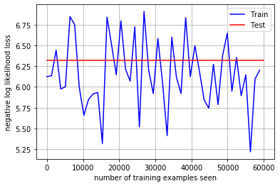

[figure not shown]

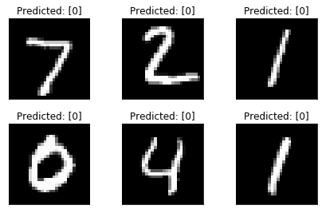

```python
from __future__ import print_function
import torch
import torch.nn as nn
import torch.nn.functional as F
import torch.optim as optim
from torchvision import datasets, transforms
import matplotlib.pyplot as plt
%matplotlib inline

# Training hyperparameters
epochs = 1
batch_size = 64
learning_rate = 0 # TODO
momentum = 0.9
weight_decay = 0 # TODO
log_interval = 20

class CNN(nn.Module):
    def __init__(self):
        super(CNN, self).__init__()
        self.conv1 = nn.Conv2d(in_channels=1, out_channels=16,
                               kernel_size=5, stride=1, padding=0)
        self.maxpool = nn.MaxPool2d(2)
        self.conv2 = nn.Conv2d(in_channels=16, out_channels=32,
                               kernel_size=3, stride=1, padding=0)
        self.fc1 = nn.Linear(in_features=800, out_features=128)
        self.fc2 = nn.Linear(in_features=128, out_features=10)

        nn.init.kaiming_normal_(self.conv1.weight, nonlinearity='relu')
        nn.init.kaiming_normal_(self.conv2.weight, nonlinearity='relu')
        nn.init.kaiming_normal_(self.fc1.weight, nonlinearity='relu')
        nn.init.kaiming_normal_(self.fc2.weight, nonlinearity='linear')

    def forward(self, x):
        x = self.conv1(x)
        x = F.relu(x)
        x = self.maxpool(x)
        x = self.conv2(x)
        x = F.relu(x)
        x = self.maxpool(x)
        x = x.view(-1, 800)
        x = self.fc1(x)
        x = F.relu(x)
        x = self.fc2(x)
        return F.log_softmax(x, dim=1)

class CNN2(nn.Module):
    def __init__(self):
        super(CNN2, self).__init__()
        self.conv1 = nn.Conv2d(in_channels=1, out_channels=32,
                               kernel_size=5, stride=1, padding=2)
        self.maxpool = nn.MaxPool2d(2)
        self.conv2 = nn.Conv2d(in_channels=24, out_channels=64,
                               kernel_size=3, stride=1, padding=2)
        self.fc1 = nn.Linear(in_features=1200, out_features=196)
        self.fc2 = nn.Linear(in_features=256, out_features=10)

        nn.init.kaiming_normal_(self.conv1.weight, nonlinearity='relu')
        nn.init.kaiming_normal_(self.conv2.weight, nonlinearity='relu')
        nn.init.kaiming_normal_(self.fc1.weight, nonlinearity='relu')
        nn.init.kaiming_normal_(self.fc2.weight, nonlinearity='linear')

    def forward(self, x):
        x = self.conv1(x)
        x = F.relu(x)
        x = self.maxpool(x)
        x = self.conv2(x)
        x = F.relu(x)
        x = self.maxpool(x)
        x = x.view(-1, 3136)
        x = self.fc1(x)
        x = F.relu(x)
        x = self.fc2(x)
        return F.log_softmax(x, dim=1)

class CNN3(nn.Module):
    def __init__(self):
        super(CNN3, self).__init__()
        # TODO

    def forward(self, x):
        # TODO
        return F.log_softmax(x, dim=1)

def plot_data(data, label, text):
    fig = plt.figure()
    for i in range(6):
        plt.subplot(2,3,i+1)
        plt.tight_layout()
        plt.imshow(data[i][0], cmap='gray', interpolation='none')
        plt.title(text + ": {}".format(label[i]))
        plt.xticks([])
        plt.yticks([])
    plt.show()

def predict_batch(model, device, test_loader):
    examples = enumerate(test_loader)
    model.eval()
    with torch.no_grad():
        batch_idx, (data, target) = next(examples)
        data, target = data.to(device), target.to(device)
        output = model(data)
        pred = output.cpu().data.max(1, keepdim=True)[1] # get the index of the max log-probability
        pred = pred.numpy()
    return data.cpu().data.numpy(), target.cpu().data.numpy(), pred

def plot_graph(train_x, train_y, test_x, test_y, ylabel=''):
    fig = plt.figure()
    plt.plot(train_x, train_y, color='blue')
    plt.plot(test_x, test_y, color='red')
    plt.legend(['Train', 'Test'], loc='upper right')
    plt.xlabel('number of training examples seen')
    plt.ylabel(ylabel)
    plt.grid()
    plt.show()

def train(model, device, train_loader, optimizer, epoch, losses=[], counter=[], errors=[]):
    model.train()
    correct=0
    for batch_idx, (data, target) in enumerate(train_loader):
        data, target = data.to(device), target.to(device)
        optimizer.zero_grad()
        output = model(data)
        loss = F.nll_loss(output, target)
        loss.backward()
        optimizer.step()
        if batch_idx % log_interval == 0:
            print('Train Epoch: {} [{}/{} ({:.0f}%)]\tLoss: {:.6f}'.format(
                epoch, batch_idx * len(data), len(train_loader.dataset),
                100. * batch_idx / len(train_loader), loss.item()))
            losses.append(loss.item())
            counter.append((batch_idx*batch_size) + ((epoch-1)*len(train_loader.dataset)))
        pred = output.max(1, keepdim=True)[1]
        correct += pred.eq(target.view_as(pred)).sum().item()
    errors.append(100. * (1 - correct / len(train_loader.dataset)))

def test(model, device, test_loader, losses=[], errors=[]):
    model.eval()
    test_loss = 0
    correct = 0
    with torch.no_grad():
        for data, target in test_loader:
            data, target = data.to(device), target.to(device)
            output = model(data)
            test_loss += F.nll_loss(output, target, reduction='sum').item() # sum up batch loss
            pred = output.max(1, keepdim=True)[1] # get the index of the max log-probability
            correct += pred.eq(target.view_as(pred)).sum().item()

    test_loss /= len(test_loader.dataset)
    print('\nTest set: Average loss: {:.4f}, Accuracy: {}/{} ({:.0f}%)\n'.format(
        test_loss, correct, len(test_loader.dataset),
        100. * correct / len(test_loader.dataset)))
    losses.append(test_loss)
    errors.append(100. *  (1 - correct / len(test_loader.dataset)))

def main():
    use_cuda = torch.cuda.is_available()
    device = torch.device("cuda" if use_cuda else "cpu")

    # data transformation
    train_data = datasets.MNIST('../data', train=True, download=True,
                   transform=transforms.Compose([
                       transforms.ToTensor(),
                       transforms.Normalize((0.1307,), (0.3081,))
                   ]))
    test_data = datasets.MNIST('../data', train=False,
                   transform=transforms.Compose([
                       transforms.ToTensor(),
                       transforms.Normalize((0.1307,), (0.3081,))
                   ]))

    # data loaders
    kwargs = {'num_workers': 1, 'pin_memory': True} if use_cuda else {}
    train_loader = torch.utils.data.DataLoader(train_data, batch_size=batch_size, shuffle=True, **kwargs)
    test_loader = torch.utils.data.DataLoader(test_data, batch_size=batch_size, shuffle=False, **kwargs)

	# extract and plot random samples of data
    #examples = enumerate(test_loader)
    #batch_idx, (data, target) = next(examples)
    #plot_data(data, target, 'Ground truth')

    # model creation
    model = CNN().to(device)
    # optimizer creation
    optimizer = optim.SGD(model.parameters(), lr=0, momentum=momentum, weight_decay=0)

    # lists for saving history
    train_losses = []
    train_counter = []
    test_losses = []
    test_counter = [i*len(train_loader.dataset) for i in range(epochs + 1)]
    train_errors = []
    test_errors = []
    error_counter = [i*len(train_loader.dataset) for i in range(epochs)]

    # test of randomly initialized model
    test(model, device, test_loader, losses=test_losses)

    # global training and testing loop
    for epoch in range(1, epochs + 1):
        train(model, device, train_loader, optimizer, epoch, losses=train_losses, counter=train_counter, errors=train_errors)
        test(model, device, test_loader, losses=test_losses, errors=test_errors)

    # plotting training history
    plot_graph(train_counter, train_losses, test_counter, test_losses, ylabel='negative log likelihood loss')
    plot_graph(error_counter, train_errors, error_counter, test_errors, ylabel='error (%)')

    # extract and plot random samples of data with predicted labels
    data, _, pred = predict_batch(model, device, test_loader)
    plot_data(data, pred, 'Predicted')

if __name__ == '__main__':
    main()
```

```python
Below code and output after changing the Learning Rate and Weight Decay:
```

```
Test set: Average loss: 3.7025, Accuracy: 1116/10000 (11%)

Train Epoch: 1 [0/60000 (0%)]	Loss: 3.738490
Train Epoch: 1 [1280/60000 (2%)]	Loss: 1.353105
Train Epoch: 1 [2560/60000 (4%)]	Loss: 0.611259
Train Epoch: 1 [3840/60000 (6%)]	Loss: 0.422794
Train Epoch: 1 [5120/60000 (9%)]	Loss: 0.318000
Train Epoch: 1 [6400/60000 (11%)]	Loss: 0.332877
Train Epoch: 1 [7680/60000 (13%)]	Loss: 0.208570
Train Epoch: 1 [8960/60000 (15%)]	Loss: 0.342509
Train Epoch: 1 [10240/60000 (17%)]	Loss: 0.332101
Train Epoch: 1 [11520/60000 (19%)]	Loss: 0.167836
Train Epoch: 1 [12800/60000 (21%)]	Loss: 0.286128
Train Epoch: 1 [14080/60000 (23%)]	Loss: 0.237261
Train Epoch: 1 [15360/60000 (26%)]	Loss: 0.224915
Train Epoch: 1 [16640/60000 (28%)]	Loss: 0.169437
Train Epoch: 1 [17920/60000 (30%)]	Loss: 0.197005
Train Epoch: 1 [19200/60000 (32%)]	Loss: 0.178348
Train Epoch: 1 [20480/60000 (34%)]	Loss: 0.200875
Train Epoch: 1 [21760/60000 (36%)]	Loss: 0.206595
Train Epoch: 1 [23040/60000 (38%)]	Loss: 0.176913
Train Epoch: 1 [24320/60000 (41%)]	Loss: 0.206739
Train Epoch: 1 [25600/60000 (43%)]	Loss: 0.230556
Train Epoch: 1 [26880/60000 (45%)]	Loss: 0.326533
Train Epoch: 1 [28160/60000 (47%)]	Loss: 0.215657
Train Epoch: 1 [29440/60000 (49%)]	Loss: 0.129892
Train Epoch: 1 [30720/60000 (51%)]	Loss: 0.237191
Train Epoch: 1 [32000/60000 (53%)]	Loss: 0.170533
Train Epoch: 1 [33280/60000 (55%)]	Loss: 0.167370
Train Epoch: 1 [34560/60000 (58%)]	Loss: 0.193724
Train Epoch: 1 [35840/60000 (60%)]	Loss: 0.121023
Train Epoch: 1 [37120/60000 (62%)]	Loss: 0.189334
Train Epoch: 1 [38400/60000 (64%)]	Loss: 0.160952
Train Epoch: 1 [39680/60000 (66%)]	Loss: 0.259934
Train Epoch: 1 [40960/60000 (68%)]	Loss: 0.125594
Train Epoch: 1 [42240/60000 (70%)]	Loss: 0.239453
Train Epoch: 1 [43520/60000 (72%)]	Loss: 0.153260
Train Epoch: 1 [44800/60000 (75%)]	Loss: 0.200455
Train Epoch: 1 [46080/60000 (77%)]	Loss: 0.158004
Train Epoch: 1 [47360/60000 (79%)]	Loss: 0.141487
Train Epoch: 1 [48640/60000 (81%)]	Loss: 0.188903
Train Epoch: 1 [49920/60000 (83%)]	Loss: 0.206817
Train Epoch: 1 [51200/60000 (85%)]	Loss: 0.186263
Train Epoch: 1 [52480/60000 (87%)]	Loss: 0.147199
Train Epoch: 1 [53760/60000 (90%)]	Loss: 0.158288
Train Epoch: 1 [55040/60000 (92%)]	Loss: 0.193892
Train Epoch: 1 [56320/60000 (94%)]	Loss: 0.212181
Train Epoch: 1 [57600/60000 (96%)]	Loss: 0.246525
Train Epoch: 1 [58880/60000 (98%)]	Loss: 0.154279

Test set: Average loss: 0.1572, Accuracy: 9599/10000 (96%)
```

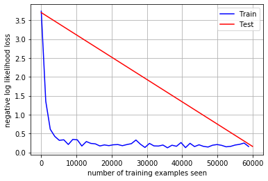

[figure not shown]

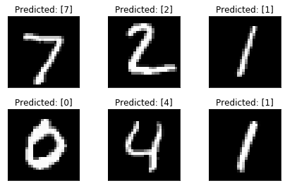

```python
from __future__ import print_function
import torch
import torch.nn as nn
import torch.nn.functional as F
import torch.optim as optim
from torchvision import datasets, transforms
import matplotlib.pyplot as plt
%matplotlib inline

# Training hyperparameters
epochs = 1
batch_size = 64
learning_rate = 0.002 # TODO
momentum = 0.9
weight_decay = 0.05 # TODO
log_interval = 20

class CNN(nn.Module):
    def __init__(self):
        super(CNN, self).__init__()
        self.conv1 = nn.Conv2d(in_channels=1, out_channels=16,
                               kernel_size=5, stride=1, padding=0)
        self.maxpool = nn.MaxPool2d(2)
        self.conv2 = nn.Conv2d(in_channels=16, out_channels=32,
                               kernel_size=3, stride=1, padding=0)
        self.fc1 = nn.Linear(in_features=800, out_features=128)
        self.fc2 = nn.Linear(in_features=128, out_features=10)

        nn.init.kaiming_normal_(self.conv1.weight, nonlinearity='relu')
        nn.init.kaiming_normal_(self.conv2.weight, nonlinearity='relu')
        nn.init.kaiming_normal_(self.fc1.weight, nonlinearity='relu')
        nn.init.kaiming_normal_(self.fc2.weight, nonlinearity='linear')

    def forward(self, x):
        x = self.conv1(x)
        x = F.relu(x)
        x = self.maxpool(x)
        x = self.conv2(x)
        x = F.relu(x)
        x = self.maxpool(x)
        x = x.view(-1, 800)
        x = self.fc1(x)
        x = F.relu(x)
        x = self.fc2(x)
        return F.log_softmax(x, dim=1)

class CNN2(nn.Module):
    def __init__(self):
        super(CNN2, self).__init__()
        self.conv1 = nn.Conv2d(in_channels=1, out_channels=32,
                               kernel_size=5, stride=1, padding=2)
        self.maxpool = nn.MaxPool2d(2)
        self.conv2 = nn.Conv2d(in_channels=24, out_channels=64,
                               kernel_size=3, stride=1, padding=2)
        self.fc1 = nn.Linear(in_features=1200, out_features=196)
        self.fc2 = nn.Linear(in_features=256, out_features=10)

        nn.init.kaiming_normal_(self.conv1.weight, nonlinearity='relu')
        nn.init.kaiming_normal_(self.conv2.weight, nonlinearity='relu')
        nn.init.kaiming_normal_(self.fc1.weight, nonlinearity='relu')
        nn.init.kaiming_normal_(self.fc2.weight, nonlinearity='linear')

    def forward(self, x):
        x = self.conv1(x)
        x = F.relu(x)
        x = self.maxpool(x)
        x = self.conv2(x)
        x = F.relu(x)
        x = self.maxpool(x)
        x = x.view(-1, 3136)
        x = self.fc1(x)
        x = F.relu(x)
        x = self.fc2(x)
        return F.log_softmax(x, dim=1)

class CNN3(nn.Module):
    def __init__(self):
        super(CNN3, self).__init__()
        # TODO

    def forward(self, x):
        # TODO
        return F.log_softmax(x, dim=1)

def plot_data(data, label, text):
    fig = plt.figure()
    for i in range(6):
        plt.subplot(2,3,i+1)
        plt.tight_layout()
        plt.imshow(data[i][0], cmap='gray', interpolation='none')
        plt.title(text + ": {}".format(label[i]))
        plt.xticks([])
        plt.yticks([])
    plt.show()

def predict_batch(model, device, test_loader):
    examples = enumerate(test_loader)
    model.eval()
    with torch.no_grad():
        batch_idx, (data, target) = next(examples)
        data, target = data.to(device), target.to(device)
        output = model(data)
        pred = output.cpu().data.max(1, keepdim=True)[1] # get the index of the max log-probability
        pred = pred.numpy()
    return data.cpu().data.numpy(), target.cpu().data.numpy(), pred

def plot_graph(train_x, train_y, test_x, test_y, ylabel=''):
    fig = plt.figure()
    plt.plot(train_x, train_y, color='blue')
    plt.plot(test_x, test_y, color='red')
    plt.legend(['Train', 'Test'], loc='upper right')
    plt.xlabel('number of training examples seen')
    plt.ylabel(ylabel)
    plt.grid()
    plt.show()

def train(model, device, train_loader, optimizer, epoch, losses=[], counter=[], errors=[]):
    model.train()
    correct=0
    for batch_idx, (data, target) in enumerate(train_loader):
        data, target = data.to(device), target.to(device)
        optimizer.zero_grad()
        output = model(data)
        loss = F.nll_loss(output, target)
        loss.backward()
        optimizer.step()
        if batch_idx % log_interval == 0:
            print('Train Epoch: {} [{}/{} ({:.0f}%)]\tLoss: {:.6f}'.format(
                epoch, batch_idx * len(data), len(train_loader.dataset),
                100. * batch_idx / len(train_loader), loss.item()))
            losses.append(loss.item())
            counter.append((batch_idx*batch_size) + ((epoch-1)*len(train_loader.dataset)))
        pred = output.max(1, keepdim=True)[1]
        correct += pred.eq(target.view_as(pred)).sum().item()
    errors.append(100. * (1 - correct / len(train_loader.dataset)))

def test(model, device, test_loader, losses=[], errors=[]):
    model.eval()
    test_loss = 0
    correct = 0
    with torch.no_grad():
        for data, target in test_loader:
            data, target = data.to(device), target.to(device)
            output = model(data)
            test_loss += F.nll_loss(output, target, reduction='sum').item() # sum up batch loss
            pred = output.max(1, keepdim=True)[1] # get the index of the max log-probability
            correct += pred.eq(target.view_as(pred)).sum().item()

    test_loss /= len(test_loader.dataset)
    print('\nTest set: Average loss: {:.4f}, Accuracy: {}/{} ({:.0f}%)\n'.format(
        test_loss, correct, len(test_loader.dataset),
        100. * correct / len(test_loader.dataset)))
    losses.append(test_loss)
    errors.append(100. *  (1 - correct / len(test_loader.dataset)))

def main():
    use_cuda = torch.cuda.is_available()
    device = torch.device("cuda" if use_cuda else "cpu")

    # data transformation
    train_data = datasets.MNIST('../data', train=True, download=True,
                   transform=transforms.Compose([
                       transforms.ToTensor(),
                       transforms.Normalize((0.1307,), (0.3081,))
                   ]))
    test_data = datasets.MNIST('../data', train=False,
                   transform=transforms.Compose([
                       transforms.ToTensor(),
                       transforms.Normalize((0.1307,), (0.3081,))
                   ]))

    # data loaders
    kwargs = {'num_workers': 1, 'pin_memory': True} if use_cuda else {}
    train_loader = torch.utils.data.DataLoader(train_data, batch_size=batch_size, shuffle=True, **kwargs)
    test_loader = torch.utils.data.DataLoader(test_data, batch_size=batch_size, shuffle=False, **kwargs)

	# extract and plot random samples of data
    #examples = enumerate(test_loader)
    #batch_idx, (data, target) = next(examples)
    #plot_data(data, target, 'Ground truth')

    # model creation
    model = CNN().to(device)
    # optimizer creation
    optimizer = optim.SGD(model.parameters(), lr=learning_rate, momentum=momentum, weight_decay=weight_decay)

    # lists for saving history
    train_losses = []
    train_counter = []
    test_losses = []
    test_counter = [i*len(train_loader.dataset) for i in range(epochs + 1)]
    train_errors = []
    test_errors = []
    error_counter = [i*len(train_loader.dataset) for i in range(epochs)]

    # test of randomly initialized model
    test(model, device, test_loader, losses=test_losses)

    # global training and testing loop
    for epoch in range(1, epochs + 1):
        train(model, device, train_loader, optimizer, epoch, losses=train_losses, counter=train_counter, errors=train_errors)
        test(model, device, test_loader, losses=test_losses, errors=test_errors)

    # plotting training history
    plot_graph(train_counter, train_losses, test_counter, test_losses, ylabel='negative log likelihood loss')
    plot_graph(error_counter, train_errors, error_counter, test_errors, ylabel='error (%)')

    # extract and plot random samples of data with predicted labels
    data, _, pred = predict_batch(model, device, test_loader)
    plot_data(data, pred, 'Predicted')

if __name__ == '__main__':
    main()
```

```
Test set: Average loss: 3.3357, Accuracy: 929/10000 (9%)

Train Epoch: 1 [0/60000 (0%)]	Loss: 3.004022
Train Epoch: 1 [1280/60000 (2%)]	Loss: 0.785839
Train Epoch: 1 [2560/60000 (4%)]	Loss: 0.457113
Train Epoch: 1 [3840/60000 (6%)]	Loss: 0.323117
Train Epoch: 1 [5120/60000 (9%)]	Loss: 0.329837
Train Epoch: 1 [6400/60000 (11%)]	Loss: 0.254839
Train Epoch: 1 [7680/60000 (13%)]	Loss: 0.391953
Train Epoch: 1 [8960/60000 (15%)]	Loss: 0.255508
Train Epoch: 1 [10240/60000 (17%)]	Loss: 0.220013
Train Epoch: 1 [11520/60000 (19%)]	Loss: 0.373497
Train Epoch: 1 [12800/60000 (21%)]	Loss: 0.287305
Train Epoch: 1 [14080/60000 (23%)]	Loss: 0.151599
Train Epoch: 1 [15360/60000 (26%)]	Loss: 0.169571
Train Epoch: 1 [16640/60000 (28%)]	Loss: 0.075984
Train Epoch: 1 [17920/60000 (30%)]	Loss: 0.259454
Train Epoch: 1 [19200/60000 (32%)]	Loss: 0.197943
Train Epoch: 1 [20480/60000 (34%)]	Loss: 0.169782
Train Epoch: 1 [21760/60000 (36%)]	Loss: 0.255318
Train Epoch: 1 [23040/60000 (38%)]	Loss: 0.143630
Train Epoch: 1 [24320/60000 (41%)]	Loss: 0.129424
Train Epoch: 1 [25600/60000 (43%)]	Loss: 0.195563
Train Epoch: 1 [26880/60000 (45%)]	Loss: 0.150360
Train Epoch: 1 [28160/60000 (47%)]	Loss: 0.246372
Train Epoch: 1 [29440/60000 (49%)]	Loss: 0.196534
Train Epoch: 1 [30720/60000 (51%)]	Loss: 0.292629
Train Epoch: 1 [32000/60000 (53%)]	Loss: 0.153946
Train Epoch: 1 [33280/60000 (55%)]	Loss: 0.108821
Train Epoch: 1 [34560/60000 (58%)]	Loss: 0.115857
Train Epoch: 1 [35840/60000 (60%)]	Loss: 0.149201
Train Epoch: 1 [37120/60000 (62%)]	Loss: 0.236756
Train Epoch: 1 [38400/60000 (64%)]	Loss: 0.119847
Train Epoch: 1 [39680/60000 (66%)]	Loss: 0.192827
Train Epoch: 1 [40960/60000 (68%)]	Loss: 0.183132
Train Epoch: 1 [42240/60000 (70%)]	Loss: 0.138624
Train Epoch: 1 [43520/60000 (72%)]	Loss: 0.121952
Train Epoch: 1 [44800/60000 (75%)]	Loss: 0.240094
Train Epoch: 1 [46080/60000 (77%)]	Loss: 0.187521
Train Epoch: 1 [47360/60000 (79%)]	Loss: 0.109393
Train Epoch: 1 [48640/60000 (81%)]	Loss: 0.212155
Train Epoch: 1 [49920/60000 (83%)]	Loss: 0.302179
Train Epoch: 1 [51200/60000 (85%)]	Loss: 0.194922
Train Epoch: 1 [52480/60000 (87%)]	Loss: 0.151213
Train Epoch: 1 [53760/60000 (90%)]	Loss: 0.110398
Train Epoch: 1 [55040/60000 (92%)]	Loss: 0.260966
Train Epoch: 1 [56320/60000 (94%)]	Loss: 0.247251
Train Epoch: 1 [57600/60000 (96%)]	Loss: 0.153522
Train Epoch: 1 [58880/60000 (98%)]	Loss: 0.217299

Test set: Average loss: 0.1489, Accuracy: 9621/10000 (96%)
```

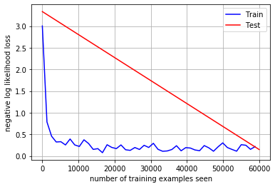

[figure not shown]

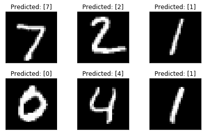

```python
from __future__ import print_function
import torch
import torch.nn as nn
import torch.nn.functional as F
import torch.optim as optim
from torchvision import datasets, transforms
import matplotlib.pyplot as plt
%matplotlib inline

# Training hyperparameters
epochs = 1
batch_size = 64
learning_rate = 0.002 # TODO
momentum = 0.9
weight_decay = 0.05 # TODO
log_interval = 20

class CNN(nn.Module):
    def __init__(self):
        super(CNN, self).__init__()
        self.conv1 = nn.Conv2d(in_channels=1, out_channels=16,
                               kernel_size=5, stride=1, padding=0)
        self.maxpool = nn.MaxPool2d(2)
        self.conv2 = nn.Conv2d(in_channels=16, out_channels=32,
                               kernel_size=3, stride=1, padding=0)
        self.fc1 = nn.Linear(in_features=800, out_features=128)
        self.fc2 = nn.Linear(in_features=128, out_features=10)

        nn.init.kaiming_normal_(self.conv1.weight, nonlinearity='relu')
        nn.init.kaiming_normal_(self.conv2.weight, nonlinearity='relu')
        nn.init.kaiming_normal_(self.fc1.weight, nonlinearity='relu')
        nn.init.kaiming_normal_(self.fc2.weight, nonlinearity='linear')

    def forward(self, x):
        x = self.conv1(x)
        x = F.relu(x)
        x = self.maxpool(x)
        x = self.conv2(x)
        x = F.relu(x)
        x = self.maxpool(x)
        x = x.view(-1, 800)
        x = self.fc1(x)
        x = F.relu(x)
        x = self.fc2(x)
        return F.log_softmax(x, dim=1)

class CNN2(nn.Module):
    def __init__(self):
        super(CNN2, self).__init__()
        self.conv1 = nn.Conv2d(in_channels=1, out_channels=32,
                               kernel_size=5, stride=1, padding=2)
        self.maxpool = nn.MaxPool2d(2)
        self.conv2 = nn.Conv2d(in_channels=32, out_channels=64,
                               kernel_size=5, stride=1, padding=2)
        self.fc1 = nn.Linear(in_features=3136, out_features=256)
        self.fc2 = nn.Linear(in_features=256, out_features=10)

        nn.init.kaiming_normal_(self.conv1.weight, nonlinearity='relu')
        nn.init.kaiming_normal_(self.conv2.weight, nonlinearity='relu')
        nn.init.kaiming_normal_(self.fc1.weight, nonlinearity='relu')
        nn.init.kaiming_normal_(self.fc2.weight, nonlinearity='linear')

    def forward(self, x):
        x = self.conv1(x)
        x = F.relu(x)
        x = self.maxpool(x)
        x = self.conv2(x)
        x = F.relu(x)
        x = self.maxpool(x)
        x = x.view(-1, 3136)
        x = self.fc1(x)
        x = F.relu(x)
        x = self.fc2(x)
        return F.log_softmax(x, dim=1)

class CNN3(nn.Module):
    def __init__(self):
        super(CNN3, self).__init__()
        # TODO

    def forward(self, x):
        # TODO
        return F.log_softmax(x, dim=1)

def plot_data(data, label, text):
    fig = plt.figure()
    for i in range(6):
        plt.subplot(2,3,i+1)
        plt.tight_layout()
        plt.imshow(data[i][0], cmap='gray', interpolation='none')
        plt.title(text + ": {}".format(label[i]))
        plt.xticks([])
        plt.yticks([])
    plt.show()

def predict_batch(model, device, test_loader):
    examples = enumerate(test_loader)
    model.eval()
    with torch.no_grad():
        batch_idx, (data, target) = next(examples)
        data, target = data.to(device), target.to(device)
        output = model(data)
        pred = output.cpu().data.max(1, keepdim=True)[1] # get the index of the max log-probability
        pred = pred.numpy()
    return data.cpu().data.numpy(), target.cpu().data.numpy(), pred

def plot_graph(train_x, train_y, test_x, test_y, ylabel=''):
    fig = plt.figure()
    plt.plot(train_x, train_y, color='blue')
    plt.plot(test_x, test_y, color='red')
    plt.legend(['Train', 'Test'], loc='upper right')
    plt.xlabel('number of training examples seen')
    plt.ylabel(ylabel)
    plt.grid()
    plt.show()

def train(model, device, train_loader, optimizer, epoch, losses=[], counter=[], errors=[]):
    model.train()
    correct=0
    for batch_idx, (data, target) in enumerate(train_loader):
        data, target = data.to(device), target.to(device)
        optimizer.zero_grad()
        output = model(data)
        loss = F.nll_loss(output, target)
        loss.backward()
        optimizer.step()
        if batch_idx % log_interval == 0:
            print('Train Epoch: {} [{}/{} ({:.0f}%)]\tLoss: {:.6f}'.format(
                epoch, batch_idx * len(data), len(train_loader.dataset),
                100. * batch_idx / len(train_loader), loss.item()))
            losses.append(loss.item())
            counter.append((batch_idx*batch_size) + ((epoch-1)*len(train_loader.dataset)))
        pred = output.max(1, keepdim=True)[1]
        correct += pred.eq(target.view_as(pred)).sum().item()
    errors.append(100. * (1 - correct / len(train_loader.dataset)))

def test(model, device, test_loader, losses=[], errors=[]):
    model.eval()
    test_loss = 0
    correct = 0
    with torch.no_grad():
        for data, target in test_loader:
            data, target = data.to(device), target.to(device)
            output = model(data)
            test_loss += F.nll_loss(output, target, reduction='sum').item() # sum up batch loss
            pred = output.max(1, keepdim=True)[1] # get the index of the max log-probability
            correct += pred.eq(target.view_as(pred)).sum().item()

    test_loss /= len(test_loader.dataset)
    print('\nTest set: Average loss: {:.4f}, Accuracy: {}/{} ({:.0f}%)\n'.format(
        test_loss, correct, len(test_loader.dataset),
        100. * correct / len(test_loader.dataset)))
    losses.append(test_loss)
    errors.append(100. *  (1 - correct / len(test_loader.dataset)))

def main():
    use_cuda = torch.cuda.is_available()
    device = torch.device("cuda" if use_cuda else "cpu")

    # data transformation
    train_data = datasets.MNIST('../data', train=True, download=True,
                   transform=transforms.Compose([
                       transforms.ToTensor(),
                       transforms.Normalize((0.1307,), (0.3081,))
                   ]))
    test_data = datasets.MNIST('../data', train=False,
                   transform=transforms.Compose([
                       transforms.ToTensor(),
                       transforms.Normalize((0.1307,), (0.3081,))
                   ]))

    # data loaders
    kwargs = {'num_workers': 1, 'pin_memory': True} if use_cuda else {}
    train_loader = torch.utils.data.DataLoader(train_data, batch_size=batch_size, shuffle=True, **kwargs)
    test_loader = torch.utils.data.DataLoader(test_data, batch_size=batch_size, shuffle=False, **kwargs)

	# extract and plot random samples of data
    #examples = enumerate(test_loader)
    #batch_idx, (data, target) = next(examples)
    #plot_data(data, target, 'Ground truth')

    # model creation
    model = CNN2().to(device)
    # optimizer creation
    optimizer = optim.SGD(model.parameters(), lr=learning_rate, momentum=momentum, weight_decay=weight_decay)

    # lists for saving history
    train_losses = []
    train_counter = []
    test_losses = []
    test_counter = [i*len(train_loader.dataset) for i in range(epochs + 1)]
    train_errors = []
    test_errors = []
    error_counter = [i*len(train_loader.dataset) for i in range(epochs)]

    # test of randomly initialized model
    test(model, device, test_loader, losses=test_losses)

    # global training and testing loop
    for epoch in range(1, epochs + 1):
        train(model, device, train_loader, optimizer, epoch, losses=train_losses, counter=train_counter, errors=train_errors)
        test(model, device, test_loader, losses=test_losses, errors=test_errors)

    # plotting training history
    plot_graph(train_counter, train_losses, test_counter, test_losses, ylabel='negative log likelihood loss')
    plot_graph(error_counter, train_errors, error_counter, test_errors, ylabel='error (%)')

    # extract and plot random samples of data with predicted labels
    data, _, pred = predict_batch(model, device, test_loader)
    plot_data(data, pred, 'Predicted')

if __name__ == '__main__':
    main()
```

2.c) Change dataset to fashion MNIST (https://research.zalando.com/welcome/mission/researchprojects/fashion-mnist/, hint: take a look at torchvision.datasets), estimate the dataset mean and standard deviation and use it to normalize the data in the data loader:

```
Mean of MNIST_Fashion Dataset tensor(0.2860)
Standard Deivation of MNIST_Fashion Dataset tensor(0.3530)

Test set: Average loss: 3.8401, Accuracy: 959/10000 (10%)

Train Epoch: 1 [0/60000 (0%)]	Loss: 3.617915
Train Epoch: 1 [1280/60000 (2%)]	Loss: 0.891251
Train Epoch: 1 [2560/60000 (4%)]	Loss: 0.528206
Train Epoch: 1 [3840/60000 (6%)]	Loss: 0.618565
Train Epoch: 1 [5120/60000 (9%)]	Loss: 0.574659
Train Epoch: 1 [6400/60000 (11%)]	Loss: 0.457416
Train Epoch: 1 [7680/60000 (13%)]	Loss: 0.601376
Train Epoch: 1 [8960/60000 (15%)]	Loss: 0.537283
Train Epoch: 1 [10240/60000 (17%)]	Loss: 0.486489
Train Epoch: 1 [11520/60000 (19%)]	Loss: 0.559667
Train Epoch: 1 [12800/60000 (21%)]	Loss: 0.570990
Train Epoch: 1 [14080/60000 (23%)]	Loss: 0.475648
Train Epoch: 1 [15360/60000 (26%)]	Loss: 0.488746
Train Epoch: 1 [16640/60000 (28%)]	Loss: 0.471682
Train Epoch: 1 [17920/60000 (30%)]	Loss: 0.525368
Train Epoch: 1 [19200/60000 (32%)]	Loss: 0.495907
Train Epoch: 1 [20480/60000 (34%)]	Loss: 0.491391
Train Epoch: 1 [21760/60000 (36%)]	Loss: 0.522675
Train Epoch: 1 [23040/60000 (38%)]	Loss: 0.651319
Train Epoch: 1 [24320/60000 (41%)]	Loss: 0.711224
Train Epoch: 1 [25600/60000 (43%)]	Loss: 0.636330
Train Epoch: 1 [26880/60000 (45%)]	Loss: 0.448580
Train Epoch: 1 [28160/60000 (47%)]	Loss: 0.529386
Train Epoch: 1 [29440/60000 (49%)]	Loss: 0.378527
Train Epoch: 1 [30720/60000 (51%)]	Loss: 0.541682
Train Epoch: 1 [32000/60000 (53%)]	Loss: 0.398243
Train Epoch: 1 [33280/60000 (55%)]	Loss: 0.550820
Train Epoch: 1 [34560/60000 (58%)]	Loss: 0.403907
Train Epoch: 1 [35840/60000 (60%)]	Loss: 0.455073
Train Epoch: 1 [37120/60000 (62%)]	Loss: 0.521120
Train Epoch: 1 [38400/60000 (64%)]	Loss: 0.622492
Train Epoch: 1 [39680/60000 (66%)]	Loss: 0.454672
Train Epoch: 1 [40960/60000 (68%)]	Loss: 0.473894
Train Epoch: 1 [42240/60000 (70%)]	Loss: 0.493985
Train Epoch: 1 [43520/60000 (72%)]	Loss: 0.666843
Train Epoch: 1 [44800/60000 (75%)]	Loss: 0.450119
Train Epoch: 1 [46080/60000 (77%)]	Loss: 0.531225
Train Epoch: 1 [47360/60000 (79%)]	Loss: 0.389781
Train Epoch: 1 [48640/60000 (81%)]	Loss: 0.498514
Train Epoch: 1 [49920/60000 (83%)]	Loss: 0.546377
Train Epoch: 1 [51200/60000 (85%)]	Loss: 0.498421
Train Epoch: 1 [52480/60000 (87%)]	Loss: 0.541714
Train Epoch: 1 [53760/60000 (90%)]	Loss: 0.465445
Train Epoch: 1 [55040/60000 (92%)]	Loss: 0.387423
Train Epoch: 1 [56320/60000 (94%)]	Loss: 0.529183
Train Epoch: 1 [57600/60000 (96%)]	Loss: 0.511736
Train Epoch: 1 [58880/60000 (98%)]	Loss: 0.566769

Test set: Average loss: 0.5100, Accuracy: 8213/10000 (82%)
```

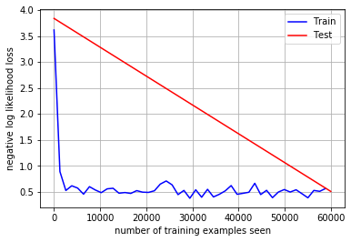

[figure not shown]

[figure not shown]

```python
from __future__ import print_function
import torch
import torch.nn as nn
import torch.nn.functional as F
import torch.optim as optim
from torchvision import datasets, transforms
import matplotlib.pyplot as plt
%matplotlib inline

# Training hyperparameters
epochs = 1
batch_size = 64
learning_rate = 0.002 # TODO
momentum = 0.9
weight_decay = 0.05 # TODO
log_interval = 20

class CNN(nn.Module):
    def __init__(self):
        super(CNN, self).__init__()
        self.conv1 = nn.Conv2d(in_channels=1, out_channels=16,
                               kernel_size=5, stride=1, padding=0)
        self.maxpool = nn.MaxPool2d(2)
        self.conv2 = nn.Conv2d(in_channels=16, out_channels=32,
                               kernel_size=3, stride=1, padding=0)
        self.fc1 = nn.Linear(in_features=800, out_features=128)
        self.fc2 = nn.Linear(in_features=128, out_features=10)

        nn.init.kaiming_normal_(self.conv1.weight, nonlinearity='relu')
        nn.init.kaiming_normal_(self.conv2.weight, nonlinearity='relu')
        nn.init.kaiming_normal_(self.fc1.weight, nonlinearity='relu')
        nn.init.kaiming_normal_(self.fc2.weight, nonlinearity='linear')

    def forward(self, x):
        x = self.conv1(x)
        x = F.relu(x)
        x = self.maxpool(x)
        x = self.conv2(x)
        x = F.relu(x)
        x = self.maxpool(x)
        x = x.view(-1, 800)
        x = self.fc1(x)
        x = F.relu(x)
        x = self.fc2(x)
        return F.log_softmax(x, dim=1)

class CNN2(nn.Module):
    def __init__(self):
        super(CNN2, self).__init__()
        self.conv1 = nn.Conv2d(in_channels=1, out_channels=32,
                               kernel_size=5, stride=1, padding=2)
        self.maxpool = nn.MaxPool2d(2)
        self.conv2 = nn.Conv2d(in_channels=32, out_channels=64,
                               kernel_size=5, stride=1, padding=2)
        self.fc1 = nn.Linear(in_features=3136, out_features=256)
        self.fc2 = nn.Linear(in_features=256, out_features=10)

        nn.init.kaiming_normal_(self.conv1.weight, nonlinearity='relu')
        nn.init.kaiming_normal_(self.conv2.weight, nonlinearity='relu')
        nn.init.kaiming_normal_(self.fc1.weight, nonlinearity='relu')
        nn.init.kaiming_normal_(self.fc2.weight, nonlinearity='linear')

    def forward(self, x):
        x = self.conv1(x)
        x = F.relu(x)
        x = self.maxpool(x)
        x = self.conv2(x)
        x = F.relu(x)
        x = self.maxpool(x)
        x = x.view(-1, 3136)
        x = self.fc1(x)
        x = F.relu(x)
        x = self.fc2(x)
        return F.log_softmax(x, dim=1)

class CNN3(nn.Module):
    def __init__(self):
        super(CNN3, self).__init__()
        # TODO

    def forward(self, x):
        # TODO
        return F.log_softmax(x, dim=1)

def plot_data(data, label, text):
    fig = plt.figure()
    for i in range(6):
        plt.subplot(2,3,i+1)
        plt.tight_layout()
        plt.imshow(data[i][0], cmap='gray', interpolation='none')
        plt.title(text + ": {}".format(label[i]))
        plt.xticks([])
        plt.yticks([])
    plt.show()

def predict_batch(model, device, test_loader):
    examples = enumerate(test_loader)
    model.eval()
    with torch.no_grad():
        batch_idx, (data, target) = next(examples)
        data, target = data.to(device), target.to(device)
        output = model(data)
        pred = output.cpu().data.max(1, keepdim=True)[1] # get the index of the max log-probability
        pred = pred.numpy()
    return data.cpu().data.numpy(), target.cpu().data.numpy(), pred

def plot_graph(train_x, train_y, test_x, test_y, ylabel=''):
    fig = plt.figure()
    plt.plot(train_x, train_y, color='blue')
    plt.plot(test_x, test_y, color='red')
    plt.legend(['Train', 'Test'], loc='upper right')
    plt.xlabel('number of training examples seen')
    plt.ylabel(ylabel)
    plt.grid()
    plt.show()

def train(model, device, train_loader, optimizer, epoch, losses=[], counter=[], errors=[]):
    model.train()
    correct=0
    for batch_idx, (data, target) in enumerate(train_loader):
        data, target = data.to(device), target.to(device)
        optimizer.zero_grad()
        output = model(data)
        loss = F.nll_loss(output, target)
        loss.backward()
        optimizer.step()
        if batch_idx % log_interval == 0:
            print('Train Epoch: {} [{}/{} ({:.0f}%)]\tLoss: {:.6f}'.format(
                epoch, batch_idx * len(data), len(train_loader.dataset),
                100. * batch_idx / len(train_loader), loss.item()))
            losses.append(loss.item())
            counter.append((batch_idx*batch_size) + ((epoch-1)*len(train_loader.dataset)))
        pred = output.max(1, keepdim=True)[1]
        correct += pred.eq(target.view_as(pred)).sum().item()
    errors.append(100. * (1 - correct / len(train_loader.dataset)))

def test(model, device, test_loader, losses=[], errors=[]):
    model.eval()
    test_loss = 0
    correct = 0
    with torch.no_grad():
        for data, target in test_loader:
            data, target = data.to(device), target.to(device)
            output = model(data)
            test_loss += F.nll_loss(output, target, reduction='sum').item() # sum up batch loss
            pred = output.max(1, keepdim=True)[1] # get the index of the max log-probability
            correct += pred.eq(target.view_as(pred)).sum().item()

    test_loss /= len(test_loader.dataset)
    print('\nTest set: Average loss: {:.4f}, Accuracy: {}/{} ({:.0f}%)\n'.format(
        test_loss, correct, len(test_loader.dataset),
        100. * correct / len(test_loader.dataset)))
    losses.append(test_loss)
    errors.append(100. *  (1 - correct / len(test_loader.dataset)))

def main():
    use_cuda = torch.cuda.is_available()
    device = torch.device("cuda" if use_cuda else "cpu")

    # data transformation
    train_data = datasets.FashionMNIST('../data', train=True, download=True,
                   transform=transforms.Compose([
                       transforms.ToTensor(),
                       transforms.Normalize((0.2860,), (0.3530,))
                   ]))
    test_data = datasets.FashionMNIST('../data', train=False,
                   transform=transforms.Compose([
                       transforms.ToTensor(),
                       transforms.Normalize((0.2860,), (0.3530,))
                   ]))

    #Mean and Standard Deviation for MNIST_Fashion
    print("Mean of MNIST_Fashion Dataset",train_data.data.float().mean()/255)
    print("Standard Deivation of MNIST_Fashion Dataset",train_data.data.float().std()/255)

    # data loaders
    kwargs = {'num_workers': 1, 'pin_memory': True} if use_cuda else {}
    train_loader = torch.utils.data.DataLoader(train_data, batch_size=batch_size, shuffle=True, **kwargs)
    test_loader = torch.utils.data.DataLoader(test_data, batch_size=batch_size, shuffle=False, **kwargs)

	# extract and plot random samples of data
    #examples = enumerate(test_loader)
    #batch_idx, (data, target) = next(examples)
    #plot_data(data, target, 'Ground truth')

    # model creation
    model = CNN2().to(device)
    # optimizer creation
    optimizer = optim.SGD(model.parameters(), lr=learning_rate, momentum=momentum, weight_decay=weight_decay)

    # lists for saving history
    train_losses = []
    train_counter = []
    test_losses = []
    test_counter = [i*len(train_loader.dataset) for i in range(epochs + 1)]
    train_errors = []
    test_errors = []
    error_counter = [i*len(train_loader.dataset) for i in range(epochs)]

    # test of randomly initialized model
    test(model, device, test_loader, losses=test_losses)

    # global training and testing loop
    for epoch in range(1, epochs + 1):
        train(model, device, train_loader, optimizer, epoch, losses=train_losses, counter=train_counter, errors=train_errors)
        test(model, device, test_loader, losses=test_losses, errors=test_errors)

    # plotting training history
    plot_graph(train_counter, train_losses, test_counter, test_losses, ylabel='negative log likelihood loss')
    plot_graph(error_counter, train_errors, error_counter, test_errors, ylabel='error (%)')

    # extract and plot random samples of data with predicted labels
    data, _, pred = predict_batch(model, device, test_loader)
    plot_data(data, pred, 'Predicted')

if __name__ == '__main__':
    main()
```

1.d) Design CNN3 with additional regularization of your choosing. Explain benefits of such regularization and report its accurracy on fashion MNIST and its relative improvement over CNN2:

```
Mean of MNIST_Fashion Dataset tensor(0.2860)
Standard Deivation of MNIST_Fashion Dataset tensor(0.3530)

Test set: Average loss: 3.4406, Accuracy: 1008/10000 (10%)

Train Epoch: 1 [0/60000 (0%)]	Loss: 4.686841
Train Epoch: 1 [1280/60000 (2%)]	Loss: 1.089941
Train Epoch: 1 [2560/60000 (4%)]	Loss: 0.939096
Train Epoch: 1 [3840/60000 (6%)]	Loss: 0.811201
Train Epoch: 1 [5120/60000 (9%)]	Loss: 0.710193
Train Epoch: 1 [6400/60000 (11%)]	Loss: 0.727615
Train Epoch: 1 [7680/60000 (13%)]	Loss: 0.528904
Train Epoch: 1 [8960/60000 (15%)]	Loss: 0.552515
Train Epoch: 1 [10240/60000 (17%)]	Loss: 0.738761
Train Epoch: 1 [11520/60000 (19%)]	Loss: 0.515923
Train Epoch: 1 [12800/60000 (21%)]	Loss: 0.586331
Train Epoch: 1 [14080/60000 (23%)]	Loss: 0.400038
Train Epoch: 1 [15360/60000 (26%)]	Loss: 0.741449
Train Epoch: 1 [16640/60000 (28%)]	Loss: 0.591903
Train Epoch: 1 [17920/60000 (30%)]	Loss: 0.453762
Train Epoch: 1 [19200/60000 (32%)]	Loss: 0.398647
Train Epoch: 1 [20480/60000 (34%)]	Loss: 0.648264
Train Epoch: 1 [21760/60000 (36%)]	Loss: 0.454670
Train Epoch: 1 [23040/60000 (38%)]	Loss: 0.608103
Train Epoch: 1 [24320/60000 (41%)]	Loss: 0.510818
Train Epoch: 1 [25600/60000 (43%)]	Loss: 0.352644
Train Epoch: 1 [26880/60000 (45%)]	Loss: 0.544431
Train Epoch: 1 [28160/60000 (47%)]	Loss: 0.445107
Train Epoch: 1 [29440/60000 (49%)]	Loss: 0.568347
Train Epoch: 1 [30720/60000 (51%)]	Loss: 0.653349
Train Epoch: 1 [32000/60000 (53%)]	Loss: 0.659944
Train Epoch: 1 [33280/60000 (55%)]	Loss: 0.512507
Train Epoch: 1 [34560/60000 (58%)]	Loss: 0.473926
Train Epoch: 1 [35840/60000 (60%)]	Loss: 0.542911
Train Epoch: 1 [37120/60000 (62%)]	Loss: 0.342875
Train Epoch: 1 [38400/60000 (64%)]	Loss: 0.620396
Train Epoch: 1 [39680/60000 (66%)]	Loss: 0.442837
Train Epoch: 1 [40960/60000 (68%)]	Loss: 0.500238
Train Epoch: 1 [42240/60000 (70%)]	Loss: 0.532904
Train Epoch: 1 [43520/60000 (72%)]	Loss: 0.427905
Train Epoch: 1 [44800/60000 (75%)]	Loss: 0.513971
Train Epoch: 1 [46080/60000 (77%)]	Loss: 0.437114
Train Epoch: 1 [47360/60000 (79%)]	Loss: 0.462744
Train Epoch: 1 [48640/60000 (81%)]	Loss: 0.500035
Train Epoch: 1 [49920/60000 (83%)]	Loss: 0.374139
Train Epoch: 1 [51200/60000 (85%)]	Loss: 0.379785
Train Epoch: 1 [52480/60000 (87%)]	Loss: 0.510120
Train Epoch: 1 [53760/60000 (90%)]	Loss: 0.471696
Train Epoch: 1 [55040/60000 (92%)]	Loss: 0.471070
Train Epoch: 1 [56320/60000 (94%)]	Loss: 0.608240
Train Epoch: 1 [57600/60000 (96%)]	Loss: 0.564545
Train Epoch: 1 [58880/60000 (98%)]	Loss: 0.400217

Test set: Average loss: 0.6441, Accuracy: 8177/10000 (82%)
```

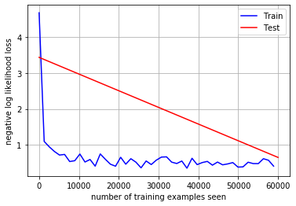

[figure not shown]

[figure not shown]

```python
from __future__ import print_function
import torch
import torch.nn as nn
import torch.nn.functional as F
import torch.optim as optim
from torchvision import datasets, transforms
import matplotlib.pyplot as plt
%matplotlib inline

# Training hyperparameters
epochs = 1
batch_size = 64
learning_rate = 0.002 # TODO
momentum = 0.9
weight_decay = 0.05 # TODO
log_interval = 20

class CNN(nn.Module):
    def __init__(self):
        super(CNN, self).__init__()
        self.conv1 = nn.Conv2d(in_channels=1, out_channels=16,
                               kernel_size=5, stride=1, padding=0)
        self.maxpool = nn.MaxPool2d(2)
        self.conv2 = nn.Conv2d(in_channels=16, out_channels=32,
                               kernel_size=3, stride=1, padding=0)
        self.fc1 = nn.Linear(in_features=800, out_features=128)
        self.fc2 = nn.Linear(in_features=128, out_features=10)

        nn.init.kaiming_normal_(self.conv1.weight, nonlinearity='relu')
        nn.init.kaiming_normal_(self.conv2.weight, nonlinearity='relu')
        nn.init.kaiming_normal_(self.fc1.weight, nonlinearity='relu')
        nn.init.kaiming_normal_(self.fc2.weight, nonlinearity='linear')

    def forward(self, x):
        x = self.conv1(x)
        x = F.relu(x)
        x = self.maxpool(x)
        x = self.conv2(x)
        x = F.relu(x)
        x = self.maxpool(x)
        x = x.view(-1, 800)
        x = self.fc1(x)
        x = F.relu(x)
        x = self.fc2(x)
        return F.log_softmax(x, dim=1)

class CNN2(nn.Module):
    def __init__(self):
        super(CNN2, self).__init__()
        self.conv1 = nn.Conv2d(in_channels=1, out_channels=32,
                               kernel_size=5, stride=1, padding=2)
        self.maxpool = nn.MaxPool2d(2)
        self.conv2 = nn.Conv2d(in_channels=32, out_channels=64,
                               kernel_size=5, stride=1, padding=2)
        self.fc1 = nn.Linear(in_features=3136, out_features=256)
        self.fc2 = nn.Linear(in_features=256, out_features=10)

        nn.init.kaiming_normal_(self.conv1.weight, nonlinearity='relu')
        nn.init.kaiming_normal_(self.conv2.weight, nonlinearity='relu')
        nn.init.kaiming_normal_(self.fc1.weight, nonlinearity='relu')
        nn.init.kaiming_normal_(self.fc2.weight, nonlinearity='linear')

    def forward(self, x):
        x = self.conv1(x)
        x = F.relu(x)
        x = self.maxpool(x)
        x = self.conv2(x)
        x = F.relu(x)
        x = self.maxpool(x)
        x = x.view(-1, 3136)
        x = self.fc1(x)
        x = F.relu(x)
        x = self.fc2(x)
        return F.log_softmax(x, dim=1)

class CNN3(nn.Module):
    def __init__(self):
        super(CNN3, self).__init__()
        self.conv1 = nn.Conv2d(in_channels=1, out_channels=32,
                               kernel_size=5, stride=1, padding=2)
        self.dropout1=nn.Dropout(0.5)
        self.maxpool = nn.MaxPool2d(2)
        self.conv2 = nn.Conv2d(in_channels=32, out_channels=64,
                               kernel_size=5, stride=1, padding=2)
        self.fc1 = nn.Linear(in_features=3136, out_features=256)
        self.fc2 = nn.Linear(in_features=256, out_features=10)

        nn.init.kaiming_normal_(self.conv1.weight, nonlinearity='relu')
        nn.init.kaiming_normal_(self.conv2.weight, nonlinearity='relu')
        nn.init.kaiming_normal_(self.fc1.weight, nonlinearity='relu')
        nn.init.kaiming_normal_(self.fc2.weight, nonlinearity='linear')

    def forward(self, x):
        x = self.conv1(x)
        x = F.relu(x)
        x = self.dropout1(x)
        x = self.maxpool(x)
        x = self.conv2(x)
        x = F.relu(x)
        x = self.maxpool(x)
        x = x.view(-1, 3136)
        x = self.fc1(x)
        x = F.relu(x)
        x = self.fc2(x)
        return F.log_softmax(x, dim=1)

def plot_data(data, label, text):
    fig = plt.figure()
    for i in range(6):
        plt.subplot(2,3,i+1)
        plt.tight_layout()
        plt.imshow(data[i][0], cmap='gray', interpolation='none')
        plt.title(text + ": {}".format(label[i]))
        plt.xticks([])
        plt.yticks([])
    plt.show()

def predict_batch(model, device, test_loader):
    examples = enumerate(test_loader)
    model.eval()
    with torch.no_grad():
        batch_idx, (data, target) = next(examples)
        data, target = data.to(device), target.to(device)
        output = model(data)
        pred = output.cpu().data.max(1, keepdim=True)[1] # get the index of the max log-probability
        pred = pred.numpy()
    return data.cpu().data.numpy(), target.cpu().data.numpy(), pred

def plot_graph(train_x, train_y, test_x, test_y, ylabel=''):
    fig = plt.figure()
    plt.plot(train_x, train_y, color='blue')
    plt.plot(test_x, test_y, color='red')
    plt.legend(['Train', 'Test'], loc='upper right')
    plt.xlabel('number of training examples seen')
    plt.ylabel(ylabel)
    plt.grid()
    plt.show()

def train(model, device, train_loader, optimizer, epoch, losses=[], counter=[], errors=[]):
    model.train()
    correct=0
    for batch_idx, (data, target) in enumerate(train_loader):
        data, target = data.to(device), target.to(device)
        optimizer.zero_grad()
        output = model(data)
        loss = F.nll_loss(output, target)
        loss.backward()
        optimizer.step()
        if batch_idx % log_interval == 0:
            print('Train Epoch: {} [{}/{} ({:.0f}%)]\tLoss: {:.6f}'.format(
                epoch, batch_idx * len(data), len(train_loader.dataset),
                100. * batch_idx / len(train_loader), loss.item()))
            losses.append(loss.item())
            counter.append((batch_idx*batch_size) + ((epoch-1)*len(train_loader.dataset)))
        pred = output.max(1, keepdim=True)[1]
        correct += pred.eq(target.view_as(pred)).sum().item()
    errors.append(100. * (1 - correct / len(train_loader.dataset)))

def test(model, device, test_loader, losses=[], errors=[]):
    model.eval()
    test_loss = 0
    correct = 0
    with torch.no_grad():
        for data, target in test_loader:
            data, target = data.to(device), target.to(device)
            output = model(data)
            test_loss += F.nll_loss(output, target, reduction='sum').item() # sum up batch loss
            pred = output.max(1, keepdim=True)[1] # get the index of the max log-probability
            correct += pred.eq(target.view_as(pred)).sum().item()

    test_loss /= len(test_loader.dataset)
    print('\nTest set: Average loss: {:.4f}, Accuracy: {}/{} ({:.0f}%)\n'.format(
        test_loss, correct, len(test_loader.dataset),
        100. * correct / len(test_loader.dataset)))
    losses.append(test_loss)
    errors.append(100. *  (1 - correct / len(test_loader.dataset)))

def main():
    use_cuda = torch.cuda.is_available()
    device = torch.device("cuda" if use_cuda else "cpu")

    # data transformation
    train_data = datasets.FashionMNIST('../data', train=True, download=True,
                   transform=transforms.Compose([
                       transforms.ToTensor(),
                       transforms.Normalize((0.2860,), (0.3530,))
                   ]))
    test_data = datasets.FashionMNIST('../data', train=False,
                   transform=transforms.Compose([
                       transforms.ToTensor(),
                       transforms.Normalize((0.2860,), (0.3530,))
                   ]))

    #Mean and Standard Deviation for MNIST_Fashion
    print("Mean of MNIST_Fashion Dataset",train_data.data.float().mean()/255)
    print("Standard Deivation of MNIST_Fashion Dataset",train_data.data.float().std()/255)

    # data loaders
    kwargs = {'num_workers': 1, 'pin_memory': True} if use_cuda else {}
    train_loader = torch.utils.data.DataLoader(train_data, batch_size=batch_size, shuffle=True, **kwargs)
    test_loader = torch.utils.data.DataLoader(test_data, batch_size=batch_size, shuffle=False, **kwargs)

	# extract and plot random samples of data
    #examples = enumerate(test_loader)
    #batch_idx, (data, target) = next(examples)
    #plot_data(data, target, 'Ground truth')

    # model creation
    model = CNN3().to(device)
    # optimizer creation
    optimizer = optim.SGD(model.parameters(), lr=learning_rate, momentum=momentum, weight_decay=weight_decay)

    # lists for saving history
    train_losses = []
    train_counter = []
    test_losses = []
    test_counter = [i*len(train_loader.dataset) for i in range(epochs + 1)]
    train_errors = []
    test_errors = []
    error_counter = [i*len(train_loader.dataset) for i in range(epochs)]

    # test of randomly initialized model
    test(model, device, test_loader, losses=test_losses)

    # global training and testing loop
    for epoch in range(1, epochs + 1):
        train(model, device, train_loader, optimizer, epoch, losses=train_losses, counter=train_counter, errors=train_errors)
        test(model, device, test_loader, losses=test_losses, errors=test_errors)

    # plotting training history
    plot_graph(train_counter, train_losses, test_counter, test_losses, ylabel='negative log likelihood loss')
    plot_graph(error_counter, train_errors, error_counter, test_errors, ylabel='error (%)')

    # extract and plot random samples of data with predicted labels
    data, _, pred = predict_batch(model, device, test_loader)
    plot_data(data, pred, 'Predicted')

if __name__ == '__main__':
    main()
```

1.e) Download file YourEmail_in.csv from the course drive. File contains 5x5 array of integers X. Manualy compute valid convolution of w and X and submit output in file named YourEmail_out.csv (note the difference between convolution and cross-correlation

=> Answer is submitted in GUPTAH@TCD.IE_out.csv

1.f) Download file YourEmail_network.csv from the course drive. File contains network definiton in the following format: i) Convolution, N, K – convolution layer with N feature maps and KxK filters ii) Maxpool, K – max pooling layer KxK pooling window iii) Fully-connected, N – fully connected layer with N neurons All convolutions use same padding that preserves input feature size. All convolutional and fully-connected layers use bias. The network is applied on 32x32 RGB images (3 input channels). Calculate the number of parameters and the number of FLOPS of this network and submit them in YourEmail_params.csv each of the 2 values in separate row (number of parameters in the first row)

=> Answer is submitted in GUPTAH@TCD.IE_params.csv

2) Image denoising:Read paper Beyond a Gaussian Denoiser: Residual Learning of Deep CNN for Image Denoising (https://arxiv.org/abs/1608.03981). From the class drive download archive DnCNN.zip which contains the dataset, data preparation, training and testing scripts. You are provided with DnCNN-s model pretrained to denoise images with σ=25

2.a) Briefly explain how the authors have decided on the particular network depth. Which tasks is the DnCNN-3 designed to solve?

2.b) Use main_test.py to test the pretrained model on denoising the whole Set68 with σ=25 and report the obtained average PSNR and SSIM metrics. Download YourEmail_sigma.csv that contains specific value of σ. Test the same model on the same set corrupted by this particular σ and report the results:

```python
# -*- coding: utf-8 -*-

# =============================================================================
#  @article{zhang2017beyond,
#    title={Beyond a {Gaussian} denoiser: Residual learning of deep {CNN} for image denoising},
#    author={Zhang, Kai and Zuo, Wangmeng and Chen, Yunjin and Meng, Deyu and Zhang, Lei},
#    journal={IEEE Transactions on Image Processing},
#    year={2017},
#    volume={26},
#    number={7},
#    pages={3142-3155},
#  }
# modified version of the code from https://github.com/cszn/DnCNN
# =============================================================================

# run this to test the model

import argparse
import os, time, datetime
import numpy as np
import torch.nn as nn
import torch.nn.init as init
import torch
from skimage.measure import compare_psnr, compare_ssim
from skimage.io import imread, imsave
import warnings
warnings.filterwarnings('ignore')


def parse_args():
    parser = argparse.ArgumentParser()
    parser.add_argument('--set_dir', default='data/Test', type=str, help='directory of test dataset')
    parser.add_argument('--set_names', default=['Set68'], help='directory of test dataset')
    parser.add_argument('--sigma', default=25, type=int, help='noise level')
    parser.add_argument('--model_path', default='models/model_000.pth', type=str, help='the model name')
    parser.add_argument('--result_dir', default='results', type=str, help='directory of test dataset')
    parser.add_argument('--save_result', action='store_true', help='save the denoised image')
    return parser.parse_args([])


def log(*args, **kwargs):
     print(datetime.datetime.now().strftime("%Y-%m-%d %H:%M:%S:"), *args, **kwargs)


def save_result(result, path):
    path = path if path.find('.') != -1 else path+'.png'
    ext = os.path.splitext(path)[-1]
    if ext in ('.txt', '.dlm'):
        np.savetxt(path, result, fmt='%2.4f')
    else:
        imsave(path, np.uint8(np.clip(result*255.0, 0, 255)))


def show(x, title=None, cbar=False, figsize=None):
    import matplotlib.pyplot as plt
    plt.figure(figsize=figsize)
    plt.imshow(x, interpolation='nearest', cmap='gray')
    if title:
        plt.title(title)
    if cbar:
        plt.colorbar()
    plt.show()


class DnCNN(nn.Module):

    def __init__(self, depth=17, n_channels=64, image_channels=1, use_bnorm=True, kernel_size=3):
        super(DnCNN, self).__init__()
        kernel_size = 3
        padding = 1
        layers = []
        layers.append(nn.Conv2d(in_channels=image_channels, out_channels=n_channels, kernel_size=kernel_size, padding=padding, bias=True))
        layers.append(nn.ReLU(inplace=True))
        for _ in range(depth-2):
            layers.append(nn.Conv2d(in_channels=n_channels, out_channels=n_channels, kernel_size=kernel_size, padding=padding, bias=False))
            layers.append(nn.BatchNorm2d(n_channels))
            layers.append(nn.ReLU(inplace=True))
        layers.append(nn.Conv2d(in_channels=n_channels, out_channels=image_channels, kernel_size=kernel_size, padding=padding, bias=False))
        self.dncnn = nn.Sequential(*layers)
        self._initialize_weights()

    def forward(self, x):
        y = x
        out = self.dncnn(x)
        return y-out

    def _initialize_weights(self):
        for m in self.modules():
            if isinstance(m, nn.Conv2d):
                init.orthogonal_(m.weight)
                print('init weight')
                if m.bias is not None:
                    init.constant_(m.bias, 0)
            elif isinstance(m, nn.BatchNorm2d):
                init.constant_(m.weight, 1)
                init.constant_(m.bias, 0)


if __name__ == '__main__':

    args = parse_args()

    model = torch.load(args.model_path)
    log('load trained model')

    model.eval()  # evaluation mode

    if torch.cuda.is_available():
        model = model.cuda()

    if not os.path.exists(args.result_dir):
        os.mkdir(args.result_dir)

    for set_cur in args.set_names:

        if not os.path.exists(os.path.join(args.result_dir, set_cur)):
            os.mkdir(os.path.join(args.result_dir, set_cur))
        psnrs = []
        ssims = []

        for im in os.listdir(os.path.join(args.set_dir, set_cur)):
            if im.endswith(".jpg") or im.endswith(".bmp") or im.endswith(".png"):

                x = np.array(imread(os.path.join(args.set_dir, set_cur, im)), dtype=np.float32)/255.0
                np.random.seed(seed=0)  # for reproducibility
                y = x + np.random.normal(0, args.sigma/255.0, x.shape)  # Add Gaussian noise without clipping
                y = y.astype(np.float32)
                y_ = torch.from_numpy(y).view(1, -1, y.shape[0], y.shape[1])

                torch.cuda.synchronize()
                start_time = time.time()
                y_ = y_.cuda()
                x_ = model(y_)  # inference
                x_ = x_.view(y.shape[0], y.shape[1])
                x_ = x_.cpu()
                x_ = x_.detach().numpy().astype(np.float32)
                torch.cuda.synchronize()
                elapsed_time = time.time() - start_time
                print('%10s : %10s : %2.4f second' % (set_cur, im, elapsed_time))

                psnr_x_ = compare_psnr(x, x_)
                ssim_x_ = compare_ssim(x, x_)
                if args.save_result:
                    name, ext = os.path.splitext(im)
                    #show(np.hstack((y, x_)))  # show the image
                    save_result(x_, path=os.path.join(args.result_dir, set_cur, name+'_dncnn'+ext))  # save the denoised image
                psnrs.append(psnr_x_)
                ssims.append(ssim_x_)
        psnr_avg = np.mean(psnrs)
        ssim_avg = np.mean(ssims)
        psnrs.append(psnr_avg)
        ssims.append(ssim_avg)
        if args.save_result:
            save_result(np.hstack((psnrs, ssims)), path=os.path.join(args.result_dir, set_cur, 'results.txt'))
        log('Datset: {0:10s} \n  PSNR = {1:2.2f}dB, SSIM = {2:1.4f}'.format(set_cur, psnr_avg, ssim_avg))
```

```
2019-11-23 14:58:03: load trained model
     Set68 : test001.png : 0.0794 second
     Set68 : test002.png : 0.0230 second
     Set68 : test003.png : 0.0309 second
     Set68 : test004.png : 0.0369 second
     Set68 : test005.png : 0.0369 second
     Set68 : test006.png : 0.0289 second
     Set68 : test007.png : 0.0250 second
     Set68 : test008.png : 0.0379 second
     Set68 : test009.png : 0.0366 second
     Set68 : test010.png : 0.0379 second
     Set68 : test011.png : 0.0379 second
     Set68 : test012.png : 0.0379 second
     Set68 : test013.png : 0.0379 second
     Set68 : test014.png : 0.0369 second
     Set68 : test015.png : 0.0369 second
     Set68 : test016.png : 0.0379 second
     Set68 : test017.png : 0.0369 second
     Set68 : test018.png : 0.0369 second
     Set68 : test019.png : 0.0369 second
     Set68 : test020.png : 0.0359 second
     Set68 : test021.png : 0.0359 second
     Set68 : test022.png : 0.0369 second
     Set68 : test023.png : 0.0369 second
     Set68 : test024.png : 0.0379 second
     Set68 : test025.png : 0.0369 second
     Set68 : test026.png : 0.0369 second
     Set68 : test027.png : 0.0369 second
     Set68 : test028.png : 0.0369 second
     Set68 : test029.png : 0.0359 second
     Set68 : test030.png : 0.0369 second
     Set68 : test031.png : 0.0369 second
     Set68 : test032.png : 0.0359 second
     Set68 : test033.png : 0.0369 second
     Set68 : test034.png : 0.0369 second
     Set68 : test035.png : 0.0309 second
     Set68 : test036.png : 0.0369 second
     Set68 : test037.png : 0.0369 second
     Set68 : test038.png : 0.0379 second
     Set68 : test039.png : 0.0220 second
```

[output cut: 16 more lines]

```
     Set68 : test056.png : 0.0369 second
     Set68 : test057.png : 0.0250 second
     Set68 : test058.png : 0.0369 second
     Set68 : test059.png : 0.0349 second
     Set68 : test060.png : 0.0369 second
     Set68 : test061.png : 0.0329 second
     Set68 : test062.png : 0.0379 second
     Set68 : test063.png : 0.0369 second
     Set68 : test064.png : 0.0369 second
     Set68 : test065.png : 0.0369 second
     Set68 : test066.png : 0.0369 second
     Set68 : test067.png : 0.0369 second
     Set68 : test068.png : 0.0399 second
2019-11-23 14:58:09: Datset: Set68
  PSNR = 29.26dB, SSIM = 0.9022
```

=> Now using sigma = 44 as given in csv:

```python
# -*- coding: utf-8 -*-

# =============================================================================
#  @article{zhang2017beyond,
#    title={Beyond a {Gaussian} denoiser: Residual learning of deep {CNN} for image denoising},
#    author={Zhang, Kai and Zuo, Wangmeng and Chen, Yunjin and Meng, Deyu and Zhang, Lei},
#    journal={IEEE Transactions on Image Processing},
#    year={2017},
#    volume={26},
#    number={7},
#    pages={3142-3155},
#  }
# modified version of the code from https://github.com/cszn/DnCNN
# =============================================================================

# run this to test the model

import argparse
import os, time, datetime
import numpy as np
import torch.nn as nn
import torch.nn.init as init
import torch
from skimage.measure import compare_psnr, compare_ssim
from skimage.io import imread, imsave
import warnings
warnings.filterwarnings('ignore')


def parse_args():
    parser = argparse.ArgumentParser()
    parser.add_argument('--set_dir', default='data/Test', type=str, help='directory of test dataset')
    parser.add_argument('--set_names', default=['Set68'], help='directory of test dataset')
    parser.add_argument('--sigma', default=44, type=int, help='noise level')
    parser.add_argument('--model_path', default='models/model_000.pth', type=str, help='the model name')
    parser.add_argument('--result_dir', default='results', type=str, help='directory of test dataset')
    parser.add_argument('--save_result', action='store_true', help='save the denoised image')
    return parser.parse_args([])


def log(*args, **kwargs):
     print(datetime.datetime.now().strftime("%Y-%m-%d %H:%M:%S:"), *args, **kwargs)


def save_result(result, path):
    path = path if path.find('.') != -1 else path+'.png'
    ext = os.path.splitext(path)[-1]
    if ext in ('.txt', '.dlm'):
        np.savetxt(path, result, fmt='%2.4f')
    else:
        imsave(path, np.uint8(np.clip(result*255.0, 0, 255)))


def show(x, title=None, cbar=False, figsize=None):
    import matplotlib.pyplot as plt
    plt.figure(figsize=figsize)
    plt.imshow(x, interpolation='nearest', cmap='gray')
    if title:
        plt.title(title)
    if cbar:
        plt.colorbar()
    plt.show()


class DnCNN(nn.Module):

    def __init__(self, depth=17, n_channels=64, image_channels=1, use_bnorm=True, kernel_size=3):
        super(DnCNN, self).__init__()
        kernel_size = 3
        padding = 1
        layers = []
        layers.append(nn.Conv2d(in_channels=image_channels, out_channels=n_channels, kernel_size=kernel_size, padding=padding, bias=True))
        layers.append(nn.ReLU(inplace=True))
        for _ in range(depth-2):
            layers.append(nn.Conv2d(in_channels=n_channels, out_channels=n_channels, kernel_size=kernel_size, padding=padding, bias=False))
            layers.append(nn.BatchNorm2d(n_channels))
            layers.append(nn.ReLU(inplace=True))
        layers.append(nn.Conv2d(in_channels=n_channels, out_channels=image_channels, kernel_size=kernel_size, padding=padding, bias=False))
        self.dncnn = nn.Sequential(*layers)
        self._initialize_weights()

    def forward(self, x):
        y = x
        out = self.dncnn(x)
        return y-out

    def _initialize_weights(self):
        for m in self.modules():
            if isinstance(m, nn.Conv2d):
                init.orthogonal_(m.weight)
                print('init weight')
                if m.bias is not None:
                    init.constant_(m.bias, 0)
            elif isinstance(m, nn.BatchNorm2d):
                init.constant_(m.weight, 1)
                init.constant_(m.bias, 0)


if __name__ == '__main__':

    args = parse_args()

    model = torch.load(args.model_path)
    log('load trained model')

    model.eval()  # evaluation mode

    if torch.cuda.is_available():
        model = model.cuda()

    if not os.path.exists(args.result_dir):
        os.mkdir(args.result_dir)

    for set_cur in args.set_names:

        if not os.path.exists(os.path.join(args.result_dir, set_cur)):
            os.mkdir(os.path.join(args.result_dir, set_cur))
        psnrs = []
        ssims = []

        for im in os.listdir(os.path.join(args.set_dir, set_cur)):
            if im.endswith(".jpg") or im.endswith(".bmp") or im.endswith(".png"):

                x = np.array(imread(os.path.join(args.set_dir, set_cur, im)), dtype=np.float32)/255.0
                np.random.seed(seed=0)  # for reproducibility
                y = x + np.random.normal(0, args.sigma/255.0, x.shape)  # Add Gaussian noise without clipping
                y = y.astype(np.float32)
                y_ = torch.from_numpy(y).view(1, -1, y.shape[0], y.shape[1])

                torch.cuda.synchronize()
                start_time = time.time()
                y_ = y_.cuda()
                x_ = model(y_)  # inference
                x_ = x_.view(y.shape[0], y.shape[1])
                x_ = x_.cpu()
                x_ = x_.detach().numpy().astype(np.float32)
                torch.cuda.synchronize()
                elapsed_time = time.time() - start_time
                print('%10s : %10s : %2.4f second' % (set_cur, im, elapsed_time))

                psnr_x_ = compare_psnr(x, x_)
                ssim_x_ = compare_ssim(x, x_)
                if args.save_result:
                    name, ext = os.path.splitext(im)
                    #show(np.hstack((y, x_)))  # show the image
                    save_result(x_, path=os.path.join(args.result_dir, set_cur, name+'_dncnn'+ext))  # save the denoised image
                psnrs.append(psnr_x_)
                ssims.append(ssim_x_)
        psnr_avg = np.mean(psnrs)
        ssim_avg = np.mean(ssims)
        psnrs.append(psnr_avg)
        ssims.append(ssim_avg)
        if args.save_result:
            save_result(np.hstack((psnrs, ssims)), path=os.path.join(args.result_dir, set_cur, 'results.txt'))
        log('Datset: {0:10s} \n  PSNR = {1:2.2f}dB, SSIM = {2:1.4f}'.format(set_cur, psnr_avg, ssim_avg))
```

```
2019-11-23 15:03:35: load trained model
     Set68 : test001.png : 0.0399 second
     Set68 : test002.png : 0.0369 second
     Set68 : test003.png : 0.0319 second
     Set68 : test004.png : 0.0369 second
     Set68 : test005.png : 0.0309 second
     Set68 : test006.png : 0.0369 second
     Set68 : test007.png : 0.0369 second
     Set68 : test008.png : 0.0369 second
     Set68 : test009.png : 0.0359 second
     Set68 : test010.png : 0.0369 second
     Set68 : test011.png : 0.0369 second
     Set68 : test012.png : 0.0389 second
     Set68 : test013.png : 0.0369 second
     Set68 : test014.png : 0.0369 second
     Set68 : test015.png : 0.0379 second
     Set68 : test016.png : 0.0369 second
     Set68 : test017.png : 0.0359 second
     Set68 : test018.png : 0.0379 second
     Set68 : test019.png : 0.0359 second
     Set68 : test020.png : 0.0379 second
     Set68 : test021.png : 0.0369 second
     Set68 : test022.png : 0.0369 second
     Set68 : test023.png : 0.0369 second
     Set68 : test024.png : 0.0369 second
     Set68 : test025.png : 0.0369 second
     Set68 : test026.png : 0.0359 second
     Set68 : test027.png : 0.0369 second
     Set68 : test028.png : 0.0359 second
     Set68 : test029.png : 0.0379 second
     Set68 : test030.png : 0.0369 second
     Set68 : test031.png : 0.0379 second
     Set68 : test032.png : 0.0379 second
     Set68 : test033.png : 0.0369 second
     Set68 : test034.png : 0.0389 second
     Set68 : test035.png : 0.0379 second
     Set68 : test036.png : 0.0379 second
     Set68 : test037.png : 0.0379 second
     Set68 : test038.png : 0.0250 second
     Set68 : test039.png : 0.0369 second
```

[output cut: 16 more lines]

```
     Set68 : test056.png : 0.0369 second
     Set68 : test057.png : 0.0369 second
     Set68 : test058.png : 0.0369 second
     Set68 : test059.png : 0.0359 second
     Set68 : test060.png : 0.0369 second
     Set68 : test061.png : 0.0379 second
     Set68 : test062.png : 0.0369 second
     Set68 : test063.png : 0.0369 second
     Set68 : test064.png : 0.0359 second
     Set68 : test065.png : 0.0379 second
     Set68 : test066.png : 0.0369 second
     Set68 : test067.png : 0.0369 second
     Set68 : test068.png : 0.0369 second
2019-11-23 15:03:39: Datset: Set68
  PSNR = 18.70dB, SSIM = 0.4228
```

2.c)Finetune the pre-trained model using script main_train.py for 1 epoch with learning rate 0.0001 with σ level given from YourEmail_sigma.csv and test its performance (PSRN/SSIM) on Set68 using this corruption level:

```python
# -*- coding: utf-8 -*-

# =============================================================================
#  @article{zhang2017beyond,
#    title={Beyond a {Gaussian} denoiser: Residual learning of deep {CNN} for image denoising},
#    author={Zhang, Kai and Zuo, Wangmeng and Chen, Yunjin and Meng, Deyu and Zhang, Lei},
#    journal={IEEE Transactions on Image Processing},
#    year={2017},
#    volume={26},
#    number={7},
#    pages={3142-3155},
#  }
# modified version of the code from https://github.com/cszn/DnCNN
# =============================================================================

# run this to test the model

import argparse
import os, time, datetime
import numpy as np
import torch.nn as nn
import torch.nn.init as init
import torch
from skimage.measure import compare_psnr, compare_ssim
from skimage.io import imread, imsave
import warnings
warnings.filterwarnings('ignore')


def parse_args():
    parser = argparse.ArgumentParser()
    parser.add_argument('--set_dir', default='data/Test', type=str, help='directory of test dataset')
    parser.add_argument('--set_names', default=['Set68'], help='directory of test dataset')
    parser.add_argument('--sigma', default=44, type=int, help='noise level')
    parser.add_argument('--model_path', default='models/model_001.pth', type=str, help='the model name')
    parser.add_argument('--result_dir', default='results', type=str, help='directory of test dataset')
    parser.add_argument('--save_result', action='store_true', help='save the denoised image')
    return parser.parse_args([])


def log(*args, **kwargs):
     print(datetime.datetime.now().strftime("%Y-%m-%d %H:%M:%S:"), *args, **kwargs)


def save_result(result, path):
    path = path if path.find('.') != -1 else path+'.png'
    ext = os.path.splitext(path)[-1]
    if ext in ('.txt', '.dlm'):
        np.savetxt(path, result, fmt='%2.4f')
    else:
        imsave(path, np.uint8(np.clip(result*255.0, 0, 255)))


def show(x, title=None, cbar=False, figsize=None):
    import matplotlib.pyplot as plt
    plt.figure(figsize=figsize)
    plt.imshow(x, interpolation='nearest', cmap='gray')
    if title:
        plt.title(title)
    if cbar:
        plt.colorbar()
    plt.show()


class DnCNN(nn.Module):

    def __init__(self, depth=17, n_channels=64, image_channels=1, use_bnorm=True, kernel_size=3):
        super(DnCNN, self).__init__()
        kernel_size = 3
        padding = 1
        layers = []
        layers.append(nn.Conv2d(in_channels=image_channels, out_channels=n_channels, kernel_size=kernel_size, padding=padding, bias=True))
        layers.append(nn.ReLU(inplace=True))
        for _ in range(depth-2):
            layers.append(nn.Conv2d(in_channels=n_channels, out_channels=n_channels, kernel_size=kernel_size, padding=padding, bias=False))
            layers.append(nn.BatchNorm2d(n_channels))
            layers.append(nn.ReLU(inplace=True))
        layers.append(nn.Conv2d(in_channels=n_channels, out_channels=image_channels, kernel_size=kernel_size, padding=padding, bias=False))
        self.dncnn = nn.Sequential(*layers)
        self._initialize_weights()

    def forward(self, x):
        y = x
        out = self.dncnn(x)
        return y-out

    def _initialize_weights(self):
        for m in self.modules():
            if isinstance(m, nn.Conv2d):
                init.orthogonal_(m.weight)
                print('init weight')
                if m.bias is not None:
                    init.constant_(m.bias, 0)
            elif isinstance(m, nn.BatchNorm2d):
                init.constant_(m.weight, 1)
                init.constant_(m.bias, 0)


if __name__ == '__main__':

    args = parse_args()

    model = torch.load(args.model_path)
    log('load trained model')

    model.eval()  # evaluation mode

    if torch.cuda.is_available():
        model = model.cuda()

    if not os.path.exists(args.result_dir):
        os.mkdir(args.result_dir)

    for set_cur in args.set_names:

        if not os.path.exists(os.path.join(args.result_dir, set_cur)):
            os.mkdir(os.path.join(args.result_dir, set_cur))
        psnrs = []
        ssims = []

        for im in os.listdir(os.path.join(args.set_dir, set_cur)):
            if im.endswith(".jpg") or im.endswith(".bmp") or im.endswith(".png"):

                x = np.array(imread(os.path.join(args.set_dir, set_cur, im)), dtype=np.float32)/255.0
                np.random.seed(seed=0)  # for reproducibility
                y = x + np.random.normal(0, args.sigma/255.0, x.shape)  # Add Gaussian noise without clipping
                y = y.astype(np.float32)
                y_ = torch.from_numpy(y).view(1, -1, y.shape[0], y.shape[1])

                torch.cuda.synchronize()
                start_time = time.time()
                y_ = y_.cuda()
                x_ = model(y_)  # inference
                x_ = x_.view(y.shape[0], y.shape[1])
                x_ = x_.cpu()
                x_ = x_.detach().numpy().astype(np.float32)
                torch.cuda.synchronize()
                elapsed_time = time.time() - start_time
                print('%10s : %10s : %2.4f second' % (set_cur, im, elapsed_time))

                psnr_x_ = compare_psnr(x, x_)
                ssim_x_ = compare_ssim(x, x_)
                if args.save_result:
                    name, ext = os.path.splitext(im)
                    #show(np.hstack((y, x_)))  # show the image
                    save_result(x_, path=os.path.join(args.result_dir, set_cur, name+'_dncnn'+ext))  # save the denoised image
                psnrs.append(psnr_x_)
                ssims.append(ssim_x_)
        psnr_avg = np.mean(psnrs)
        ssim_avg = np.mean(ssims)
        psnrs.append(psnr_avg)
        ssims.append(ssim_avg)
        if args.save_result:
            save_result(np.hstack((psnrs, ssims)), path=os.path.join(args.result_dir, set_cur, 'results.txt'))
        log('Datset: {0:10s} \n  PSNR = {1:2.2f}dB, SSIM = {2:1.4f}'.format(set_cur, psnr_avg, ssim_avg))
```

```
2019-11-23 15:09:08: load trained model
     Set68 : test001.png : 0.0389 second
     Set68 : test002.png : 0.0289 second
     Set68 : test003.png : 0.0379 second
     Set68 : test004.png : 0.0259 second
     Set68 : test005.png : 0.0369 second
     Set68 : test006.png : 0.0389 second
     Set68 : test007.png : 0.0359 second
     Set68 : test008.png : 0.0389 second
     Set68 : test009.png : 0.0389 second
     Set68 : test010.png : 0.0359 second
     Set68 : test011.png : 0.0389 second
     Set68 : test012.png : 0.0359 second
     Set68 : test013.png : 0.0369 second
     Set68 : test014.png : 0.0379 second
     Set68 : test015.png : 0.0369 second
     Set68 : test016.png : 0.0369 second
     Set68 : test017.png : 0.0369 second
     Set68 : test018.png : 0.0389 second
     Set68 : test019.png : 0.0389 second
     Set68 : test020.png : 0.0369 second
     Set68 : test021.png : 0.0379 second
     Set68 : test022.png : 0.0279 second
     Set68 : test023.png : 0.0379 second
     Set68 : test024.png : 0.0369 second
     Set68 : test025.png : 0.0379 second
     Set68 : test026.png : 0.0379 second
     Set68 : test027.png : 0.0359 second
     Set68 : test028.png : 0.0369 second
     Set68 : test029.png : 0.0369 second
     Set68 : test030.png : 0.0356 second
     Set68 : test031.png : 0.0369 second
     Set68 : test032.png : 0.0369 second
     Set68 : test033.png : 0.0250 second
     Set68 : test034.png : 0.0369 second
     Set68 : test035.png : 0.0369 second
     Set68 : test036.png : 0.0250 second
     Set68 : test037.png : 0.0349 second
     Set68 : test038.png : 0.0359 second
     Set68 : test039.png : 0.0369 second
```

[output cut: 16 more lines]

```
     Set68 : test056.png : 0.0379 second
     Set68 : test057.png : 0.0379 second
     Set68 : test058.png : 0.0379 second
     Set68 : test059.png : 0.0379 second
     Set68 : test060.png : 0.0389 second
     Set68 : test061.png : 0.0369 second
     Set68 : test062.png : 0.0379 second
     Set68 : test063.png : 0.0369 second
     Set68 : test064.png : 0.0399 second
     Set68 : test065.png : 0.0389 second
     Set68 : test066.png : 0.0409 second
     Set68 : test067.png : 0.0369 second
     Set68 : test068.png : 0.0359 second
2019-11-23 15:09:12: Datset: Set68
  PSNR = 26.79dB, SSIM = 0.8428
```

2.d)Download YourEmail_XXX.png containing corrupted version of data/Test/Set68/testXXX.png. Denoise this image with the pre-trained model, submit it as YourEmail_XXX_pretrained.png and save both PSNR, SSIM values for this image in 2 columns preserving ordering, in a file named YourEmail_psnr.csv. Repeat the procedure with your finetuned model, save result to YourEmail_XXX_clean.png and report PSNR and SSIM of this image as a second row of YourEmail_psnr.csv

```
2019-11-23 15:33:04: load trained model
```

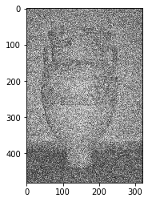

```
     Set68 : GUPTAH@TCD.IE_045.png : 0.1340 second
2019-11-23 15:33:04: Datset: Set68
  PSNR = 16.88dB, SSIM = 0.7070
```

```python
# -*- coding: utf-8 -*-

# =============================================================================
#  @article{zhang2017beyond,
#    title={Beyond a {Gaussian} denoiser: Residual learning of deep {CNN} for image denoising},
#    author={Zhang, Kai and Zuo, Wangmeng and Chen, Yunjin and Meng, Deyu and Zhang, Lei},
#    journal={IEEE Transactions on Image Processing},
#    year={2017},
#    volume={26},
#    number={7},
#    pages={3142-3155},
#  }
# modified version of the code from https://github.com/cszn/DnCNN
# =============================================================================

# run this to test the model

import argparse
import os, time, datetime
import numpy as np
import torch.nn as nn
import torch.nn.init as init
import torch
from skimage.measure import compare_psnr, compare_ssim
from skimage.io import imread, imsave
import warnings
warnings.filterwarnings('ignore')
%matplotlib inline


def parse_args():
    parser = argparse.ArgumentParser()
    parser.add_argument('--set_dir', default='data/Test1', type=str, help='directory of test dataset')
    parser.add_argument('--set_names', default=['Set68'], help='directory of test dataset')
    parser.add_argument('--sigma', default=44, type=int, help='noise level')
    parser.add_argument('--model_path', default='models/model_000.pth', type=str, help='the model name')
    parser.add_argument('--result_dir', default='results', type=str, help='directory of test dataset')
    parser.add_argument('--save_result', action='store_true', help='save the denoised image')
    return parser.parse_args([])


def log(*args, **kwargs):
     print(datetime.datetime.now().strftime("%Y-%m-%d %H:%M:%S:"), *args, **kwargs)


def save_result(result, path):
    path = path if path.find('.') != -1 else path+'.png'
    ext = os.path.splitext(path)[-1]
    if ext in ('.txt', '.dlm'):
        np.savetxt(path, result, fmt='%2.4f')
    else:
        imsave(path, np.uint8(np.clip(result*255.0, 0, 255)))


def show(x, title=None, cbar=False, figsize=None):
    import matplotlib.pyplot as plt
    plt.figure(figsize=figsize)
    plt.imshow(x, interpolation='nearest', cmap='gray')
    if title:
        plt.title(title)
    if cbar:
        plt.colorbar()
    plt.show()


class DnCNN(nn.Module):

    def __init__(self, depth=17, n_channels=64, image_channels=1, use_bnorm=True, kernel_size=3):
        super(DnCNN, self).__init__()
        kernel_size = 3
        padding = 1
        layers = []
        layers.append(nn.Conv2d(in_channels=image_channels, out_channels=n_channels, kernel_size=kernel_size, padding=padding, bias=True))
        layers.append(nn.ReLU(inplace=True))
        for _ in range(depth-2):
            layers.append(nn.Conv2d(in_channels=n_channels, out_channels=n_channels, kernel_size=kernel_size, padding=padding, bias=False))
            layers.append(nn.BatchNorm2d(n_channels))
            layers.append(nn.ReLU(inplace=True))
        layers.append(nn.Conv2d(in_channels=n_channels, out_channels=image_channels, kernel_size=kernel_size, padding=padding, bias=False))
        self.dncnn = nn.Sequential(*layers)
        self._initialize_weights()

    def forward(self, x):
        y = x
        out = self.dncnn(x)
        return y-out

    def _initialize_weights(self):
        for m in self.modules():
            if isinstance(m, nn.Conv2d):
                init.orthogonal_(m.weight)
                print('init weight')
                if m.bias is not None:
                    init.constant_(m.bias, 0)
            elif isinstance(m, nn.BatchNorm2d):
                init.constant_(m.weight, 1)
                init.constant_(m.bias, 0)


if __name__ == '__main__':

    args = parse_args()

    model = torch.load(args.model_path)
    log('load trained model')

    model.eval()  # evaluation mode

    if torch.cuda.is_available():
        model = model.cuda()

    if not os.path.exists(args.result_dir):
        os.mkdir(args.result_dir)

    for set_cur in args.set_names:

        if not os.path.exists(os.path.join(args.result_dir, set_cur)):
            os.mkdir(os.path.join(args.result_dir, set_cur))
        psnrs = []
        ssims = []

        for im in os.listdir(os.path.join(args.set_dir, set_cur)):
            if im.endswith(".jpg") or im.endswith(".bmp") or im.endswith(".png"):

                x = np.array(imread(os.path.join(args.set_dir, set_cur, im)), dtype=np.float32)/255.0
                np.random.seed(seed=0)  # for reproducibility
                y = x + np.random.normal(0, args.sigma/255.0, x.shape)  # Add Gaussian noise without clipping
                y = y.astype(np.float32)
                y_ = torch.from_numpy(y).view(1, -1, y.shape[0], y.shape[1])

                torch.cuda.synchronize()
                start_time = time.time()
                y_ = y_.cuda()
                x_ = model(y_)  # inference
                x_ = x_.view(y.shape[0], y.shape[1])
                x_ = x_.cpu()
                x_ = x_.detach().numpy().astype(np.float32)
                torch.cuda.synchronize()
                show(x_)
                save_result(x_,'GUPTAH@TCD.IE_045_PRETRAINED.png')
                elapsed_time = time.time() - start_time
                print('%10s : %10s : %2.4f second' % (set_cur, im, elapsed_time))

                psnr_x_ = compare_psnr(x, x_)
                ssim_x_ = compare_ssim(x, x_)
                if args.save_result:
                    name, ext = os.path.splitext(im)
                    #show(np.hstack((y, x_)))  # show the image
                    save_result(x_, path=os.path.join(args.result_dir, set_cur, name+'_dncnn'+ext))  # save the denoised image
                psnrs.append(psnr_x_)
                ssims.append(ssim_x_)
        psnr_avg = np.mean(psnrs)
        ssim_avg = np.mean(ssims)
        psnrs.append(psnr_avg)
        ssims.append(ssim_avg)
        if args.save_result:
            save_result(np.hstack((psnrs, ssims)), path=os.path.join(args.result_dir, set_cur, 'results.txt'))
        log('Datset: {0:10s} \n  PSNR = {1:2.2f}dB, SSIM = {2:1.4f}'.format(set_cur, psnr_avg, ssim_avg))
```

```python
pwd
```

```
'C:\\Users\\guptah\\CV Assignment\\DnCNN'
```

=> Testing on finetuned model with sigma = 44:

```
2019-11-23 15:37:04: load trained model
```

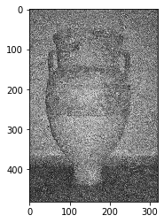

```
     Set68 : GUPTAH@TCD.IE_045.png : 0.1316 second
2019-11-23 15:37:04: Datset: Set68
  PSNR = 18.17dB, SSIM = 0.6724
```

```python
# -*- coding: utf-8 -*-

# =============================================================================
#  @article{zhang2017beyond,
#    title={Beyond a {Gaussian} denoiser: Residual learning of deep {CNN} for image denoising},
#    author={Zhang, Kai and Zuo, Wangmeng and Chen, Yunjin and Meng, Deyu and Zhang, Lei},
#    journal={IEEE Transactions on Image Processing},
#    year={2017},
#    volume={26},
#    number={7},
#    pages={3142-3155},
#  }
# modified version of the code from https://github.com/cszn/DnCNN
# =============================================================================

# run this to test the model

import argparse
import os, time, datetime
import numpy as np
import torch.nn as nn
import torch.nn.init as init
import torch
from skimage.measure import compare_psnr, compare_ssim
from skimage.io import imread, imsave
import warnings
warnings.filterwarnings('ignore')
%matplotlib inline


def parse_args():
    parser = argparse.ArgumentParser()
    parser.add_argument('--set_dir', default='data/Test1', type=str, help='directory of test dataset')
    parser.add_argument('--set_names', default=['Set68'], help='directory of test dataset')
    parser.add_argument('--sigma', default=44, type=int, help='noise level')
    parser.add_argument('--model_path', default='models/model_001.pth', type=str, help='the model name')
    parser.add_argument('--result_dir', default='results', type=str, help='directory of test dataset')
    parser.add_argument('--save_result', action='store_true', help='save the denoised image')
    return parser.parse_args([])


def log(*args, **kwargs):
     print(datetime.datetime.now().strftime("%Y-%m-%d %H:%M:%S:"), *args, **kwargs)


def save_result(result, path):
    path = path if path.find('.') != -1 else path+'.png'
    ext = os.path.splitext(path)[-1]
    if ext in ('.txt', '.dlm'):
        np.savetxt(path, result, fmt='%2.4f')
    else:
        imsave(path, np.uint8(np.clip(result*255.0, 0, 255)))


def show(x, title=None, cbar=False, figsize=None):
    import matplotlib.pyplot as plt
    plt.figure(figsize=figsize)
    plt.imshow(x, interpolation='nearest', cmap='gray')
    if title:
        plt.title(title)
    if cbar:
        plt.colorbar()
    plt.show()


class DnCNN(nn.Module):

    def __init__(self, depth=17, n_channels=64, image_channels=1, use_bnorm=True, kernel_size=3):
        super(DnCNN, self).__init__()
        kernel_size = 3
        padding = 1
        layers = []
        layers.append(nn.Conv2d(in_channels=image_channels, out_channels=n_channels, kernel_size=kernel_size, padding=padding, bias=True))
        layers.append(nn.ReLU(inplace=True))
        for _ in range(depth-2):
            layers.append(nn.Conv2d(in_channels=n_channels, out_channels=n_channels, kernel_size=kernel_size, padding=padding, bias=False))
            layers.append(nn.BatchNorm2d(n_channels))
            layers.append(nn.ReLU(inplace=True))
        layers.append(nn.Conv2d(in_channels=n_channels, out_channels=image_channels, kernel_size=kernel_size, padding=padding, bias=False))
        self.dncnn = nn.Sequential(*layers)
        self._initialize_weights()

    def forward(self, x):
        y = x
        out = self.dncnn(x)
        return y-out

    def _initialize_weights(self):
        for m in self.modules():
            if isinstance(m, nn.Conv2d):
                init.orthogonal_(m.weight)
                print('init weight')
                if m.bias is not None:
                    init.constant_(m.bias, 0)
            elif isinstance(m, nn.BatchNorm2d):
                init.constant_(m.weight, 1)
                init.constant_(m.bias, 0)


if __name__ == '__main__':

    args = parse_args()

    model = torch.load(args.model_path)
    log('load trained model')

    model.eval()  # evaluation mode

    if torch.cuda.is_available():
        model = model.cuda()

    if not os.path.exists(args.result_dir):
        os.mkdir(args.result_dir)

    for set_cur in args.set_names:

        if not os.path.exists(os.path.join(args.result_dir, set_cur)):
            os.mkdir(os.path.join(args.result_dir, set_cur))
        psnrs = []
        ssims = []

        for im in os.listdir(os.path.join(args.set_dir, set_cur)):
            if im.endswith(".jpg") or im.endswith(".bmp") or im.endswith(".png"):

                x = np.array(imread(os.path.join(args.set_dir, set_cur, im)), dtype=np.float32)/255.0
                np.random.seed(seed=0)  # for reproducibility
                y = x + np.random.normal(0, args.sigma/255.0, x.shape)  # Add Gaussian noise without clipping
                y = y.astype(np.float32)
                y_ = torch.from_numpy(y).view(1, -1, y.shape[0], y.shape[1])

                torch.cuda.synchronize()
                start_time = time.time()
                y_ = y_.cuda()
                x_ = model(y_)  # inference
                x_ = x_.view(y.shape[0], y.shape[1])
                x_ = x_.cpu()
                x_ = x_.detach().numpy().astype(np.float32)
                torch.cuda.synchronize()
                show(x_)
                save_result(x_,'GUPTAH@TCD.IE_045_CLEAN.png')
                elapsed_time = time.time() - start_time
                print('%10s : %10s : %2.4f second' % (set_cur, im, elapsed_time))

                psnr_x_ = compare_psnr(x, x_)
                ssim_x_ = compare_ssim(x, x_)
                if args.save_result:
                    name, ext = os.path.splitext(im)
                    #show(np.hstack((y, x_)))  # show the image
                    save_result(x_, path=os.path.join(args.result_dir, set_cur, name+'_dncnn'+ext))  # save the denoised image
                psnrs.append(psnr_x_)
                ssims.append(ssim_x_)
        psnr_avg = np.mean(psnrs)
        ssim_avg = np.mean(ssims)
        psnrs.append(psnr_avg)
        ssims.append(ssim_avg)
        if args.save_result:
            save_result(np.hstack((psnrs, ssims)), path=os.path.join(args.result_dir, set_cur, 'results.txt'))
        log('Datset: {0:10s} \n  PSNR = {1:2.2f}dB, SSIM = {2:1.4f}'.format(set_cur, psnr_avg, ssim_avg))
```

```python
3.a)Semantic segmentation (10 marks): Read paper Fully Convolutional Networks for Semantic
Segmentation (https://people.eecs.berkeley.edu/~jonlong/long_shelhamer_fcn.pdf). From the
class drive download script segmentation.py, containing example how to use pretrained models
for semantic segmentation.
a) Briefly explain:
i) How FCN upsamples predictions to match the original image size.
ii) How had the authors improved the coarse predictions produced by the deepest layer.
```

```python
pwd
```

```
'C:\\Users\\guptah\\CV Assignment\\DnCNN'
```

```python
cd ..
```

```
C:\Users\guptah\CV Assignment
```

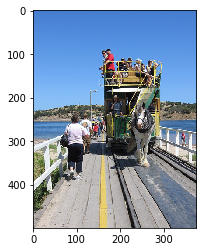

```
torch.Size([1, 21, 500, 375])
[ 0 13 15]
```

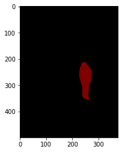

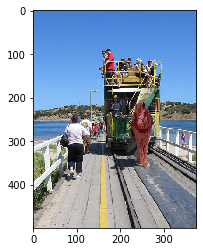

```python
# -*- coding: utf-8 -*-
"""
Based on code from
    https://colab.research.google.com/github/spmallick/learnopencv/blob/master/PyTorch-Segmentation-torchvision/intro-seg.ipynb
"""

from PIL import Image
import matplotlib.pyplot as plt
import torch
from torchvision import models
import numpy as np
import torchvision.transforms as T
import cv2


def decode_segmap(image, nc):

  label_colors = np.array([(0, 0, 0),  # 0=background
               # 1=aeroplane, 2=bicycle, 3=bird, 4=boat, 5=bottle
               (128, 0, 0), (0, 128, 0), (128, 128, 0), (0, 0, 128), (128, 0, 128),
               # 6=bus, 7=car, 8=cat, 9=chair, 10=cow
               (0, 128, 128), (128, 128, 128), (64, 0, 0), (192, 0, 0), (64, 128, 0),
               # 11=dining table, 12=dog, 13=horse, 14=motorbike, 15=person
               (192, 128, 0), (64, 0, 128), (192, 0, 128), (64, 128, 128), (192, 128, 128),
               # 16=potted plant, 17=sheep, 18=sofa, 19=train, 20=tv/monitor
               (0, 64, 0), (128, 64, 0), (0, 192, 0), (128, 192, 0), (0, 64, 128)])

  r = np.zeros_like(image).astype(np.uint8)
  g = np.zeros_like(image).astype(np.uint8)
  b = np.zeros_like(image).astype(np.uint8)

  for l in range(0, nc):
      idx = image == 13
      r[idx] = label_colors[l, 0]
      g[idx] = label_colors[l, 1]
      b[idx] = label_colors[l, 2]

  rgb = np.stack([b, r, r], axis=2)
  return rgb


def apply_mask(im, im_pred):
    """
    Overlays the predicted class labels onto an image using the alpha channel.
    This function assumes that the background label is the black color.
    This function is provided as an inspiration for the masking function you should write.
    """
    r_channel, g_channel, b_channel = cv2.split(im_pred)
    alpha_channel = 127 * np.ones(b_channel.shape, dtype=b_channel.dtype)
    # Make background pixels fully transparent
    alpha_channel -= 127 * np.all(im_pred == np.array([0, 0, 0]), axis=2).astype(b_channel.dtype)
    im_pred = cv2.merge((r_channel, g_channel, b_channel, alpha_channel))
    mask = Image.fromarray(im_pred, mode='RGBA')
    masked_img = Image.fromarray(im)
    masked_img.paste(mask, box=None, mask=mask)
    return np.array(masked_img)

# define the model
fcn = models.segmentation.fcn_resnet101(pretrained=True).eval()

# load an image
img = Image.open('./GUPTAH@TCD.IE.png')
plt.imshow(img); plt.show()

# transform the image
trf = T.Compose([T.ToTensor(),
                 T.Normalize(mean = [0.485, 0.456, 0.406],
                             std = [0.229, 0.224, 0.225])])
inp = trf(img).unsqueeze(0)

# pass the input through the net
out = fcn(inp)['out']
print (out.shape)

# calculate labels
om = torch.argmax(out.squeeze(), dim=0).detach().cpu().numpy()
print (np.unique(om))

# show segmentation output
rgb = decode_segmap(om,21)
plt.imshow(rgb); plt.show()
abc = apply_mask(np.array(img),np.array(rgb))
plt.imshow(abc); plt.show()
im=Image.fromarray(abc)
im.save("GUPTAH@TCD.IE_Predicted.png")
```

3.c)Decode the groundtruth image YourEmail_mask.png and calculate intersection over union (IOU) with the prediction for the class assigned to you. Report IOU in file YourEmail_iou.csv:

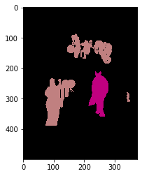

[figure not shown]

```
0.3834573304157549
```

```python
mask=Image.open('GUPTAH@TCD.IE_mask.png')
plt.imshow(mask); plt.show()
pixels=mask.load()
for i in range (np.array(mask).shape[1]):
  for j in range (np.array(mask).shape[0]):
    if not (pixels[i,j]==(192, 0, 128)): #Change based on the class values from the top
      pixels[i,j]=(0,0,0)
plt.imshow(mask); plt.show()
intersection = np.sum(np.logical_and(rgb,np.array(mask)))
union = np.sum( np.logical_or(rgb,np.array(mask)))
print(intersection/union)
```